[figure not shown]

# Introduction to Python for Data Science

# Lecture 04: Exploratory data analysis and plotting

## Student Name: Live HTML

## Student ID: NA

## 0.1.0 About Introduction to Python

Introduction to Python is brought to you by the **Centre for the Analysis of Genome Evolution & Function (CAGEF)** bioinformatics training initiative. This course was developed based on feedback on the needs and interests of the Department of Cell & Systems Biology and the Department of Ecology and Evolutionary Biology.

The structure of this course is a code-along style so it is 100% hands on! A few hours prior to each lecture, the materials will be avaialable for download at [QUERCUS](https://q.utoronto.ca/). The teaching materials will consist of a Jupyter Lab Notebook with concepts, comments, instructions, and blank spaces that you will fill out with Python code along with the instructor. Other teaching materials include a live version of the notebook, and datasets to import into Python - when required. This learning approach will allow you to spend the time coding and not taking notes!

As we go along, there will be some in-class challenge questions for you to solve either individually or in cooperation with your peers. Post lecture assessments will also be available (see syllabus for grading scheme and percentages of the final mark) through [DataCamp](https://Datacamp.com) to help cement and/or extend what you learn each week.

### 0.1.1 Where is this course headed?

We'll take a blank slate approach here to Python and assume that you pretty much know *nothing* about programming. From the beginning of this course to the end, we want to get you from some potential scenarios:

- A pile of data (like an excel file or tab-separated file) full of experimental observations and you don't know what to do with it.
- Maybe you're manipulating large tables all in excel, making custom formulas and pivot table with graphs. Now you have to repeat similar experiments and do the analysis again.
- You're generating high-throughput data and there aren't any bioinformaticians around to help you sort it out.
- You heard about Python and what it *could* do for your data analysis but don't know what that means or where to start.

and get you to a point where you can:

- Format your data correctly for analysis
- Produce basic plots and perform exploratory analysis
- Make functions and scripts for re-analysing existing or new data sets
- Track your experiments in a digital notebook like Jupyter!

### 0.1.2 How do we get there? Step-by-step.

In the first two lessons, we will talk about the basic data structures and objects in Python, get cozy with the Jupyter Notebook environment, and learn how to get help when you are stuck. Because everyone gets stuck - a lot! Then you will learn how to get your data in and out of Python, how to tidy our data (data wrangling), subset and merge data. We'll take a break from data wrangling to spend our fourth lecture learning how to generate exploratory data plots. Then we'll slide into using the power of python and programming to use flow control before visiting text manipulation techniques in lectures 5 and 6. Data cleaning and string manipulation is really the battleground of coding - getting your data into the format where you can analyse it. Lastly, we will learn to write customized functions to help scale up your analyses.

[figure not shown]

The structure of the class is a **code-along** style: It is fully hands on. At the end of each lecture, the complete notes will be made available in a PDF format through the corresponding Quercus module so you don't have to spend your attention on taking notes.

### 0.1.3 What kind of coding style will we learn?

There is no single path correct from A to B - although some paths may be more elegant, or more efficient than others. With that in mind, the emphasis in this lecture series will be on:

1. **Code simplicity** - learn helpful functions that allow you to focus on understanding the basic tenets of good data wrangling (reformatting) to facilitate quick exploratory data analysis and visualization.
2. **Code readability** - format and comment your code for yourself and others so that even those with minimal experience in R will be able to quickly grasp the overall steps in your code.
3. **Code stability** - while the core Python code is relatively stable, behaviours of functions can still change with updates. There are well-developed packages we'll focus on for our analyses. Namely, we'll become more familiar with the `pandas` series of packages for working with tabular data. This resource is well-maintained by a large community of developers. While not always the "fastest" approach this additional layer can help ensure your code still runs (somewhat) smoothly later down the road.

## 0.2.0 Lecture objectives

Welcome to this fourth lecture in a series of seven. Today we will pick up where we left off last week with our merged data. We'll learn how to explore the data, summarize it, and plot it!

At the end of this lecture we will aim to have covered the following topics:

1. Exploratory data analysis with long-format data
2. Data plotting with the `matplotlib.pyplot` package.
3. Advanced visualizations with the `seaborn` package.
4. Saving visualizations to file.

## 0.3.0 A legend for text format in Jupyter markdown

`grey background` - a package, function, code, command or directory. Backticks are also use for in-line code.  
*italics* - an important term or concept or an individual file or folder  
**bold** - heading or a term that is being defined  
blue text - named or unnamed hyperlink

`...` - Within each coding cell this will indicate an area of code that students will need to complete for the code cell to run correctly.

**Blue box:** A key concept that is being introduced

**Yellow box:** Risk or caution

**Green boxes:** Recommended reads and resources to learn Python

**Red boxes:** A comprehension question which may or may not involve a coding cell. You usually find these at the end of a section.

## 0.4.0 Lecture and data files used in this course

### 0.4.1 Weekly Lecture and skeleton files

Each week, new lesson files will appear within your JupyterHub folders. We are pulling from a GitHub repository using this [Repository git-pull link](https://jupyter.utoronto.ca/hub/user-redirect/git-pull?repo=https%3A%2F%2Fgithub.com%2Fcamok%2F2023-01-IntroPython&urlpath=tree%2F2023-01-IntroPython%2F&branch=main). Simply click on the link and it will take you to the University of Toronto JupyterHub. You will need to use your UTORid credentials to complete the login process. From there you will find each week's lecture files in the directory `/2023-01-IntroPython/Lecture_XX`. You will find a partially coded `skeleton.ipynb` file as well as all of the data files necessary to run the week's lecture.

Alternatively, you can download the Jupyter Notebook (`.ipynb`) and data files from JupyterHub to your personal computer if you would like to run independently of the JupyterHub.

### 0.4.2 Live-coding HTML page

A live lecture version will be available at [camok.github.io](https://camok.github.io/2023-01.IntroPython/index.html) that will update as the lecture progresses. Be sure to refresh to take a look if you get lost!

### 0.4.3 Post-lecture PDFs

As mentioned above, at the end of each lecture there will be a completed version of the lecture code released as a PDF file under the Modules section of Quercus.

### 0.4.4 Microsporidia infection data set description

The following datasets used in this week's class come from a preprint manuscript on bioRxiv entitled "High-throughput phenotyping of *C. elegans* wild isolates reveals specific resistance and susceptibility traits to infection by distinct microsporidia species" by [Mok et al., 2022](https://www.biorxiv.org/content/10.1101/2022.06.20.496912v1). These datasets focus on the an analysis of infection in wild isolate strains of the nematode *C. elegans* by environmental pathogens known as microsporidia. The authors collected embryo counts from individual animal in the population after population-wide infection by microsporidia and we'll spend our next few classes working with the dataset to learn how to format and manipulate it.

### 0.4.4.1 Dataset 1: /data/embryo_long_merged.csv

This is a result of our efforts (mostly) from last lecture. After transforming a wide-format version of our measurement data, we merged it with some metadata regarding our experiments and now it is ready to be visualized!

## 0.5.0 Packages used in this lesson

`IPython` and `InteractiveShell` will be access just to set the behaviour we want for iPython so we can see multiple code outputs per code cell.

`random` is a package with methods to add pseudorandomness to programs

`numpy` provides a number of mathematical functions as well as the special data class of `arrays` which we'll be learning about today.

```python
# ----- Always run this at the beginning of class so we can get multi-command output ----- #

# Access options from the iPython core
from IPython.core.interactiveshell import InteractiveShell

# Change the value of ast_node_interactivity
InteractiveShell.ast_node_interactivity = "all"

# ----- Additional packages we want to import for class ----- #

# Import the pandas package
import pandas as pd
from matplotlib import pyplot as plt
import numpy as np

# !pip install seaborn
```

# 1.0.0 An introduction to exploratory data analysis

Recall from last week, we spent our lecture converting data from the a series of worm/pathogen interactions which contained observations about the formation of spores, meronts, and embryos within individual animals in an infected population. The process involved conversion from a wide-format to long-format along with the merging of this data to a set of metadata.

Now that the wrangling is completed, we can perform some exploratory data analysis (EDA). The process of EDA investigates your data to identify abnormalities, summarize its main characteristics and identify potential patterns or trends for further validation. We did some initial statistical summarization on the numerical and non-numerical data but today we'll dig deeper using some additional tools in our Python pockets.

With our EDA today we will try to answer questions like:

1. Which worm strain or pathogen strain is most often measured/observed?
2. What is the mean number of embryos produced by uninfected animals in our study?
3. How variable is that mean across different sets of replicate experiments?
4. How many pathogen strains have been tested on each worm strain?

### 1.0.1 Import our data from last week

Let's open a version of our dataset from last week. We'll find it in the file `data/embryo_long_merged.csv`. Recall that it is always good practice to explore your data to find out more about aspects such as probability distributions, outliers, and central tendency/dispersion measures.

Now we are going to do some exploratory data analysis (EDA) on `embryo_long_merged.csv` which we made last class.

```python
# Read in embryo_long_merged.csv
embryo_merged = pd.read_csv("data/embryo_long_merged.csv")

# Take a peek at the data
embryo_merged.head()

# How big is this dataset?
embryo_merged.info()
```

|  | worm.number | date | wormStrain | pathogenStrain | pathogenDose | doseLevel | timepoint | merontsPresent | sporesPresent | numEmbryos | ... | Plate Size | Spores/cm2 | Temp | infection.type | Staining Date | Stain type | Slide date | Slide number | Slide Box | Imaging Date |
| --- | --- | --- | --- | --- | --- | --- | --- | --- | --- | --- | --- | --- | --- | --- | --- | --- | --- | --- | --- | --- | --- |
| 0 | 1 | 190426 | AB1 | LUAm1 | 0M | Mock | 72hpi | False | False | 10 | ... | 6 | 0.0 | 21 | continuous | 190430 | DY96 | 190501 | 7 | 2 | 190502 |
| 1 | 2 | 190426 | AB1 | LUAm1 | 0M | Mock | 72hpi | False | False | 9 | ... | 6 | 0.0 | 21 | continuous | 190430 | DY96 | 190501 | 7 | 2 | 190502 |
| 2 | 3 | 190426 | AB1 | LUAm1 | 0M | Mock | 72hpi | False | False | 16 | ... | 6 | 0.0 | 21 | continuous | 190430 | DY96 | 190501 | 7 | 2 | 190502 |
| 3 | 4 | 190426 | AB1 | LUAm1 | 0M | Mock | 72hpi | False | False | 13 | ... | 6 | 0.0 | 21 | continuous | 190430 | DY96 | 190501 | 7 | 2 | 190502 |
| 4 | 5 | 190426 | AB1 | LUAm1 | 0M | Mock | 72hpi | False | False | 8 | ... | 6 | 0.0 | 21 | continuous | 190430 | DY96 | 190501 | 7 | 2 | 190502 |

5 rows × 31 columns

```
<class 'pandas.core.frame.DataFrame'>
RangeIndex: 11149 entries, 0 to 11148
Data columns (total 31 columns):
 #   Column             Non-Null Count  Dtype
---  ------             --------------  -----
 0   worm.number        11149 non-null  int64
 1   date               11149 non-null  int64
 2   wormStrain         11149 non-null  object
 3   pathogenStrain     11149 non-null  object
 4   pathogenDose       11149 non-null  object
 5   doseLevel          11149 non-null  object
 6   timepoint          11149 non-null  object
 7   merontsPresent     11149 non-null  bool
 8   sporesPresent      11149 non-null  bool
 9   numEmbryos         11149 non-null  int64
```

[output cut: 23 more lines]

Before we go any further, however, let's drop some of the extraneous metadata that we won't need for our analyses. Pretty much everything from `Infection Round` onwards is unnecessary. From our call to `.info()` we can see that we just need columns up until index 19.

```python
# Subset the data from our dataset
embryo_merged_subset = embryo_merged.iloc[:, :19]

# What does the subset look like?
embryo_merged_subset.info()
```

```
<class 'pandas.core.frame.DataFrame'>
RangeIndex: 11149 entries, 0 to 11148
Data columns (total 19 columns):
 #   Column             Non-Null Count  Dtype
---  ------             --------------  -----
 0   worm.number        11149 non-null  int64
 1   date               11149 non-null  int64
 2   wormStrain         11149 non-null  object
 3   pathogenStrain     11149 non-null  object
 4   pathogenDose       11149 non-null  object
 5   doseLevel          11149 non-null  object
 6   timepoint          11149 non-null  object
 7   merontsPresent     11149 non-null  bool
 8   sporesPresent      11149 non-null  bool
 9   numEmbryos         11149 non-null  int64
 10  experiment         11149 non-null  object
 11  experimenter       11149 non-null  object
 12  description        11149 non-null  object
 13  Infection Date     11149 non-null  int64
 14  Plate Number       11149 non-null  int64
 15  Total Worms        11149 non-null  int64
 16  Spore Lot          11149 non-null  object
 17  Lot concentration  11149 non-null  int64
 18  Total ul spore     11149 non-null  float64
dtypes: bool(2), float64(1), int64(7), object(9)
memory usage: 1.5+ MB
```

## 1.1.0 Which worm and pathogen strains are most often used in our experiments?

Let's begin with a deceptively simply question about our data. As we'll see, however, it required more than a simple method call to our data in order to discern. Rather we'll walk through the thought process so you can avoid potential pitfalls later in your own analyses.

### 1.1.1 Get a summary of our information

There is a lot of subgrouped data hidden with our dataset. Experiments are classified by their `date`, `wormStrain`, `pathogenStrain`, `pathogenDose`, and `timepoint`. The combination of all five of these can also be found in the `experiment` column, although that combination may not always be useful to us.

Let's begin with the `describe()` method to review any numerical data that we can.

```python
# Get a description of the numeric data
embryo_merged_subset.describe()
```

|  | worm.number | date | numEmbryos | Infection Date | Plate Number | Total Worms | Lot concentration | Total ul spore |
| --- | --- | --- | --- | --- | --- | --- | --- | --- |
| count | 11149.000000 | 11149.00000 | 11149.000000 | 11149.000000 | 11149.000000 | 11149.000000 | 11149.00000 | 11149.000000 |
| mean | 27.499148 | 197408.14378 | 9.148444 | 197405.090143 | 18.785721 | 1309.444793 | 273701.61001 | 25.916820 |
| std | 16.460217 | 4864.97377 | 7.509851 | 4864.935158 | 15.939817 | 1678.485600 | 124153.58178 | 33.928541 |
| min | 1.000000 | 190426.00000 | 0.000000 | 190423.000000 | 1.000000 | 500.000000 | 63625.00000 | 0.000000 |
| 25% | 14.000000 | 190426.00000 | 2.000000 | 190423.000000 | 7.000000 | 1000.000000 | 176000.00000 | 0.000000 |
| 50% | 27.000000 | 200714.00000 | 9.000000 | 200711.000000 | 14.000000 | 1000.000000 | 176000.00000 | 8.196721 |
| 75% | 40.000000 | 200825.00000 | 15.000000 | 200822.000000 | 25.000000 | 1000.000000 | 427000.00000 | 56.818182 |
| max | 115.000000 | 200918.00000 | 48.000000 | 200915.000000 | 63.000000 | 10000.000000 | 427000.00000 | 113.636364 |

### 1.1.2 Use the `describe()` method to summarize non-numeric columns

Recall that we can also summarize our non-numeric data, to a certain extent, as long as we provide it properly to the `describe()` method. This method can identify the "top" occuring entry in a column as well as it's frequency. We already know that the `wormStrain` column contains the strain information on each individual worm measured in our data. The same goes for `pathogenStrain` which will contain some similar information about our pathogens used. It should be simple enough to just create a summary of that information. Let's give it a try.

```python
# Use the describe method on the OTU column from our merged_subset
embryo_merged_subset.loc[:,['wormStrain', 'pathogenStrain']].describe()
```

|  | wormStrain | pathogenStrain |
| --- | --- | --- |
| count | 11149 | 11149 |
| unique | 18 | 10 |
| top | N2 | LUAm1 |
| freq | 2941 | 5030 |

At a quick glance, we can answer our first question - that the N2 animal is the most measured one in our infection studies while the pathogen LUAm1 is the most measured pathogen in our study. There are a few catches to these results, however:

1. Although N2 is the most-often measure individual animal, this is biased by the fact that it acts as a control strain in many experiments. If we were to look at specific *groups* of experiments and how often N2 was included, would it still be the most prevalent?
2. Our measurements might be comprised of entries where LUAm1 is a `pathogenStrain`, but it's `pathogenDose` is 0! So it's not really being used to infect at all.

Let's adress the 2nd question and circle back around to the first in a little bit as it is slightly more complex.

### 1.1.3 Filter your data with conditional booleans

Last lecture we saw a few examples where we subset our data using a simple conditional statement like `isna()`. While we referred to this as "slicing" our data, you can also think of it as a way to *filter* data. We can of course, filter our data using other conditional statements and before summarizing your data, you should consider the nature of your values! In our dataset it appears that the `pathogenDose` can denote whether or not an animal was exposed to a pathogen or was "mock-infected". A mock-infected sample would have a `pathogenDose` value of 0.

To solve our issues with summarizing the pathogen usage conundrum we turn to filtering our data by the `pathogenDose` column. We'll do this in two steps:

1. Filter the dataset by a conditional.
2. Pass that dataset on for summarization.

```python
# Recall that we can broadcast a conditional query to multiple values in a DataFrame
embryo_merged_subset.loc[:, 'pathogenDose'] > 0
```

[output not shown]

Oops! The `pathogenDose` column is a string! We need to fix that up first an convert it from values like "0M" to a float value like "0.0".

Recall we have at our disposal the `pop()`, `str.split()`, `astype()`, and `insert()` methods. We'll use those now to fix the `pathogenDose` column and replace it in our `embryo_merged_subset`.

```python
# Use the insert method
embryo_merged_subset.insert(loc = 4,                   # Location to insert at
                            column = 'pathogenDose',   # The column name after insertion

                            # To calculate the value, we'll pop from the subset
                            value = (embryo_merged_subset.pop('pathogenDose')

                                     # Break up the float from the "M"
                                     .str.split(pat = "M", expand = True)

                                     # Convert the first column to a float, and then provide only that to insert
                                     .astype({0:'float64'})[0])
                           )

# Check on the updated subset data
embryo_merged_subset.info()
```

```
<class 'pandas.core.frame.DataFrame'>
RangeIndex: 11149 entries, 0 to 11148
Data columns (total 19 columns):
 #   Column             Non-Null Count  Dtype
---  ------             --------------  -----
 0   worm.number        11149 non-null  int64
 1   date               11149 non-null  int64
 2   wormStrain         11149 non-null  object
 3   pathogenStrain     11149 non-null  object
 4   pathogenDose       11149 non-null  float64
 5   doseLevel          11149 non-null  object
 6   timepoint          11149 non-null  object
 7   merontsPresent     11149 non-null  bool
 8   sporesPresent      11149 non-null  bool
 9   numEmbryos         11149 non-null  int64
 10  experiment         11149 non-null  object
 11  experimenter       11149 non-null  object
 12  description        11149 non-null  object
 13  Infection Date     11149 non-null  int64
 14  Plate Number       11149 non-null  int64
 15  Total Worms        11149 non-null  int64
 16  Spore Lot          11149 non-null  object
 17  Lot concentration  11149 non-null  int64
 18  Total ul spore     11149 non-null  float64
dtypes: bool(2), float64(2), int64(7), object(8)
memory usage: 1.5+ MB
```

Now check on that conditional filtering again!

```python
# Now we can use a conditional comparison on the pathogenDose column
embryo_merged_subset.loc[:, 'pathogenDose'] > 0
```

```
0        False
1        False
2        False
3        False
4        False
         ...
11144     True
11145     True
11146     True
11147     True
11148     True
Name: pathogenDose, Length: 11149, dtype: bool
```

```python
# Supply the result of the conditional query as a filtering criteria
print("Filtered pathogenStrain summary")
embryo_merged_subset.loc[embryo_merged_subset.loc[:, 'pathogenDose'] > 0, # remember we're filtering by rows!
                         # We only need the pathogenStrain column to summarize
                         'pathogenStrain'].describe()

print("Unfiltered pathogenStrain summary")
# Compare that to the unfiltered subset
embryo_merged_subset.loc[:, 'pathogenStrain'].describe()
```

```
Filtered pathogenStrain summary
```

```
count      7730
unique       10
top       LUAm1
freq       2838
Name: pathogenStrain, dtype: object
```

```
Unfiltered pathogenStrain summary
```

```
count     11149
unique       10
top       LUAm1
freq       5030
Name: pathogenStrain, dtype: object
```

### 1.1.4 The `.describe()` method returns a Series object

A useful aspect of the `.describe()` method is that it also returns a Series object, which means its information can be retrieved or saved for further use! Recall we can choose from the possible index names. In the case of non-numeric summaries, we can use `count`, `unique`, `top`, or `freq`. These are also 0-indexed!

```python
pathogen_Summary = embryo_merged_subset.loc[embryo_merged_subset.loc[:, 'pathogenDose'] > 0,
                         # We only need the pathogenStrain column to summarize
                         'pathogenStrain'].describe()

# Of the LUAm1 infections, which worm strain reigns supreme?
embryo_merged_subset.loc[(embryo_merged_subset["pathogenStrain"] == pathogen_Summary.top), 'wormStrain'].describe()
```

```
count     5030
unique      15
top         N2
freq       864
Name: wormStrain, dtype: object
```

### 1.1.5 Know the difference between filtering and the `filter()` method

You may be wondering to yourself, surely there must be a `filter()` method implemented with the DataFrame. It seems like such an essential part of working with DataFrames. You're right that such a method exists but you would be wrong to think that it is used for conditional filtering.

The `filter()` method is used merely for subsetting your DataFrame by column name or by regular expression pattern (See **Lecture 06**). It does not use conditional logic to subset rows from your data. While this can be helpful in certain contexts, it does NOT implement the idea of filtering rows of our data based on conditional criteria.

Here's a quick example of how to use it.

```python
# Select the wormStrain, pathogenStrain, and numEmbryos columns
embryo_merged_subset.filter(items = ['wormStrain', 'pathogenStrain', 'numEmbryos'])
```

|  | wormStrain | pathogenStrain | numEmbryos |
| --- | --- | --- | --- |
| 0 | AB1 | LUAm1 | 10 |
| 1 | AB1 | LUAm1 | 9 |
| 2 | AB1 | LUAm1 | 16 |
| 3 | AB1 | LUAm1 | 13 |
| 4 | AB1 | LUAm1 | 8 |
| ... | ... | ... | ... |
| 11144 | N2 | ERTm5-96H | 1 |
| 11145 | N2 | ERTm5-96H | 0 |
| 11146 | N2 | ERTm5-96H | 0 |
| 11147 | N2 | ERTm5-96H | 3 |
| 11148 | N2 | ERTm5-96H | 2 |

11149 rows × 3 columns

## 1.2.0 Which worm strain is most often included in our different groups?

Circling back to our first question, we discovered that N2 is the worm strain that is most often *measured* across all of our datasets, but the dataset contains groups of different infection experiments. Is N2 the most prevalent strain when we look at its inclusion within individual experiments? How do we explore this?

### 1.2.1 Grouping your DataFrame using the `groupby()` method

Thinking about our problem, we already have an identifier that breaks down each experimental grouping - `date`. Each different `date` essentially sets up a different experimental replicate. We could use our newly-taught filtering techniques, but we would have to cycle through each potential value and summarize the subset. (Honestly this would have been my approach not so long ago!).

Luckily for you, the `groupby()` method can sort all of that data for you based on the criteria you provide. The important parameters to us today are:

- `by`: A function, label, or list of labels that you want to use to determine grouping criteria. You can even provide a dictionary object where specific key:values pairs can be used to determine groupings.
- `axis`: How to split along the rows (0, default) or columns (1)
- `as_index`: A boolean to determine if the index labels should be based on group labels (True by default)

```python
# How many individual dates/replicates are there?
len(embryo_merged_subset.loc[:,'date'].unique())
```

```
11
```

```python
# Group our subset data by the 'date' column
embryo_merged_subset.groupby(by = ['date'])
```

```
<pandas.core.groupby.generic.DataFrameGroupBy object at 0x000001E3805FA380>
```

### 1.2.2 Use the `head()` method to view rows from each group

As you can see above, we create a DataFrameGroupBy object but if we attempted to look at it, it would look pretty much like the original `merged_subset`. The major difference is that the data has now been essentially sorted by the `date` column. In order to view part of it, we can use the `head(n)` method which will return `n` rows from *each* group.

```python
# Group our subset data by the 'date' column and view 1 row from each group
embryo_merged_subset.groupby(by = ['date']).head(1)
```

|  | worm.number | date | wormStrain | pathogenStrain | pathogenDose | doseLevel | timepoint | merontsPresent | sporesPresent | numEmbryos | experiment | experimenter | description | Infection Date | Plate Number | Total Worms | Spore Lot | Lot concentration | Total ul spore |
| --- | --- | --- | --- | --- | --- | --- | --- | --- | --- | --- | --- | --- | --- | --- | --- | --- | --- | --- | --- |
| 0 | 1 | 190426 | AB1 | LUAm1 | 0.0 | Mock | 72hpi | False | False | 10 | 190426_AB1_LUAm1_0M_72hpi | CM | Wild isolate phenoMIP retest | 190423 | 7 | 1000 | 2A | 176000 | 0.0 |
| 594 | 1 | 200707 | ED3052A | LUAm1 | 0.0 | Mock | 72hpi | False | False | 12 | 200707_ED3052A_LUAm1_0M_72hpi | CM | Lua1 continuous Infection test JU1400 and ED30... | 200704 | 5 | 1000 | 2A | 176000 | 0.0 |
| 842 | 1 | 200714 | ED3052A | LUAm1 | 0.0 | Mock | 72hpi | False | False | 8 | 200714_ED3052A_LUAm1_0M_72hpi | CM | Lua1 continuous Infection test JU1400 and ED3052 | 200711 | 5 | 1000 | 2A | 176000 | 0.0 |
| 1092 | 1 | 200721 | ED3052A | LUAm1 | 0.0 | Mock | 72hpi | False | False | 12 | 200721_ED3052A_LUAm1_0M_72hpi | CM | Lua1 continuous Infection test JU1400 and ED3052 | 200718 | 5 | 1000 | 2A | 176000 | 0.0 |
| 1342 | 1 | 200821 | AWR144 | LUAm1 | 0.0 | Mock | 72hpi | False | False | 23 | 200821_AWR144_LUAm1_0M_72hpi | CM | Lua1 continuous Infection test 6X NIL, VC40171... | 200818 | 7 | 1000 | 2A | 176000 | 0.0 |
| 1692 | 1 | 200825 | AWR144 | LUAm1 | 0.0 | Mock | 72hpi | False | False | 14 | 200825_AWR144_LUAm1_0M_72hpi | CM | Lua1 continuous Infection test 6X NIL, VC40171... | 200822 | 7 | 1000 | 2A | 176000 | 0.0 |
| 1942 | 1 | 200904 | AWR144 | LUAm1 | 0.0 | Mock | 72hpi | False | False | 16 | 200904_AWR144_LUAm1_0M_72hpi | CM | NIL tests for Lua1 and ERTM5, low dose ERTM5 t... | 200901 | 7 | 1000 | 2A | 176000 | 0.0 |
| 5158 | 1 | 200915 | AWR144 | ERTm5 | 0.0 | Mock | 72hpi | False | False | 19 | 200915_AWR144_ERTm5_0M_72hpi | CM | NIL tests for ERTM5 | 200912 | 5 | 1000 | 2 | 427000 | 0.0 |
| 5358 | 1 | 200918 | AWR144 | ERTm5 | 0.0 | Mock | 72hpi | False | False | 26 | 200918_AWR144_ERTm5_0M_72hpi | CM | NIL tests for ERTM5 | 200915 | 5 | 1000 | 2 | 427000 | 0.0 |
| 10551 | 1 | 200905 | JU1400 | ERTm5-96H | 0.0 | Mock | 96hpi | False | False | 9 | 200905_JU1400_ERTm5-96H_0M_96hpi | CM | NIL tests for Lua1 and ERTM5, low dose ERTM5 t... | 200901 | 26 | 1000 | 2 | 427000 | 0.0 |
| 10649 | 1 | 200916 | JU1400 | ERTm5-96H | 0.0 | Mock | 96hpi | False | False | 15 | 200916_JU1400_ERTm5-96H_0M_96hpi | CM | NIL tests for ERTM5 | 200912 | 12 | 500 | 2 | 427000 | 0.0 |

Using the `.groupby()` method and `head()`, we can view a representative observation from each group. To answer our above question, however, we need more information. If we repeat our above code but *also* include `wormStrain` and `pathogenStrain` columns in our grouping, what will that produce?

```python
# Group our subset data by the 'date' and 'wormStrain' columns and grab the first row from each
# How big is the result?
embryo_merged_subset.groupby(by = ['date', 'wormStrain', 'pathogenStrain']).head(1).shape
```

```
(99, 19)
```

### 1.2.3 Subset and apply functions to your grouped DataFrame

From our results, we see there are 99 separate combinations of `date`:`wormStrain`:`pathogenStrain` in our grouped DataFrame! Now that we have our groups we can begin to apply functions to summarize data from each group. Back to our question, we can now ask, which wormStrain produces the largest number of `date`:`wormStrain`:`pathogenStrain` combinations.

We've already used some functions like `unique()` but other helpful functions to apply include `sum()`, `max()`, `min()` and `median()`. Functions like `idxmin()` and `idxmax()` will return the *index* of the min and max values respectively but only the *first occurence* of the value being sought.

In this case what we really need is something that can help produce a frequency table. The `.value_counts()` can be applied to Series to produce such a table. We just need to provide it with the column(s) we'd like to use with the `subset` parameter.

In this case, we are interested in `wormStrain` so let's see what that looks like.

```python
# Convert the "wormStrain" column from our grouped data to a frequency table
(embryo_merged_subset.groupby(by = ['date', 'wormStrain', 'pathogenStrain']).head(1)
 # Create the frequency table
 .value_counts(subset = ['wormStrain'])
)
```

```
wormStrain
N2            29
JU1400        28
MY1            7
AWR145         6
AWR144         6
VC40171        3
VC20019        3
ED3052A        3
ED3052B        3
MY2            2
JU360          2
JU642          1
JU397          1
JU300          1
MY6            1
ED3042         1
CB4856         1
AB1            1
dtype: int64
```

So, from our groupings it looks like N2 edges out JU1400 by just a single group. That's pretty close but now we've answered our question!

## 1.3.0 What is the mean number of embryos produced by uninfected animals in our study?

Let's approach this question by identifying our criteria:

1. Filtering for uninfected animals
2. Measuring *mean* embryos across all data

```python
# Identify the mean embryo value of uninfected strains

# Subset by uninfected animals
(embryo_merged_subset.loc[embryo_merged_subset['pathogenDose'] == 0, :]

 # Group by wormStrain and take the numEmbryos colums
 .groupby(by = ['wormStrain'])['numEmbryos']

 # Calculate the mean
 .mean()
)
```

```
wormStrain
AB1        10.903226
AWR144     19.228000
AWR145     20.656000
CB4856     20.750000
ED3042     13.147541
ED3052A    10.526667
ED3052B    12.047297
JU1400     11.139501
JU300      15.622951
JU360      16.788618
JU397      11.457143
JU642      14.733333
MY1        11.725581
MY2        21.886179
MY6        18.360656
N2         18.912500
VC20019    15.143678
VC40171     4.586667
Name: numEmbryos, dtype: float64
```

### 1.3.1 Use `sort_values()` to organize your data

It looks like we get the results we're looking for but the data is sorted by alphabetical *index* order. What if we're interested, however, in finding the highest and lowest values in our dataset? Since it's small, a quick and easy way to ascertain this is with the `sort_values()` function which will sort by ascending order.

If we had a multi-column DataFrame, we could use the `by` parameter to select multiple columns to sort with.

To sort in descending or reverse order, we can set the `ascending = False` parameter.

```python
# Identify the mean embryo value of uninfected strains AND sort them!

# Subset by uninfected animals
(embryo_merged_subset.loc[embryo_merged_subset['pathogenDose'] == 0, :]

 # Group by wormStrain and take the numEmbryos colums
 .groupby(by = ['wormStrain'])['numEmbryos']

 # Calculate the mean
 .mean()

 # Sort the data by descending order
 .sort_values(ascending = False)
)
```

```
wormStrain
MY2        21.886179
CB4856     20.750000
AWR145     20.656000
AWR144     19.228000
N2         18.912500
MY6        18.360656
JU360      16.788618
JU300      15.622951
VC20019    15.143678
JU642      14.733333
ED3042     13.147541
ED3052B    12.047297
MY1        11.725581
JU397      11.457143
JU1400     11.139501
AB1        10.903226
ED3052A    10.526667
VC40171     4.586667
Name: numEmbryos, dtype: float64
```

We now have an answer to our question and have identified the mean number of embryos per uninfected animal in each strain. This is gets us a baseline value for each strain that can be used in later comparisons!

**Section 1.3.1 Comprehension Question:** Amongst all of the mean embryo values we've generated, how do we determine the median *value* in the group of means? Which strain does it belong to? Modify the code below to determine the answer.

```python
# Identify the mean embryo value of uninfected strains AND sort them!

# Subset by uninfected animals
(embryo_merged_subset.loc[embryo_merged_subset['pathogenDose'] == 0, :]

 # Group by wormStrain and take the numEmbryos colums
 .groupby(by = ['wormStrain'])['numEmbryos']

 # Calculate the mean
 .mean()

 # How do we calculate the median?
 ...
)
```

## Comprehension Question 1.3.1 Answer:

## 1.4.0 How variable is the (uninfected) mean across different sets of replicate experiments?

Now that we've got a few very helpful tools under our belt, we can take our query to the next level and ask what the mean and standard deviation of any individual worm strain is across multiple replicates.

### 1.4.1 Plan your analysis strategy to avoid mistaken assumptions

Time to think about your dataset in relationship to your question. We know already that each worm strain may appear within any infection experiment but a dose of 0 represent uninfected animals. Again, it will be important to filter our data before summarizing it. Then you must understand how to what groupings you are looking for and what measurement you'd like to summarize. Let's break down the problem:

1. Filter on uninfected animals
2. Group data by `date`, `wormStrain`, and `pathogenStrain`
3. Calculate the mean number of embryos
4. Summarize the data grouped by wormStrain

```python
# Determing the standard deviation of the mean embryo counts across each strain
# IN the uninfected state - ie a baseline embryo count.

# Filter for only uninfected data
(embryo_merged_subset.loc[embryo_merged_subset['pathogenDose'] == 0, :]

 # Group by infection experiment
 .groupby(by = ['date', 'wormStrain', 'pathogenStrain'])

 # Create the frequency table on numEmbryos
 ['numEmbryos']
 .mean()

 # Group the series of means again by wormStrain
 .groupby(by=['wormStrain'])

 # Summarize each group of numEmbryo means
 .describe()

  # Sort the data by descending order
 .sort_values(by = 'mean', ascending = False)
)
```

| wormStrain | count | mean | std | min | 25% | 50% | 75% | max |
| --- | --- | --- | --- | --- | --- | --- | --- | --- |
| MY2 | 2.0 | 21.892460 | 0.364216 | 21.634921 | 21.763690 | 21.892460 | 22.021230 | 22.150000 |
| CB4856 | 1.0 | 20.750000 | NaN | 20.750000 | 20.750000 | 20.750000 | 20.750000 | 20.750000 |
| AWR145 | 5.0 | 20.656000 | 2.160435 | 17.180000 | 20.520000 | 20.860000 | 21.760000 | 22.960000 |
| AWR144 | 5.0 | 19.228000 | 1.990407 | 16.940000 | 17.400000 | 20.060000 | 20.100000 | 21.640000 |
| N2 | 13.0 | 18.795973 | 2.816125 | 15.240000 | 16.300000 | 19.358209 | 20.880000 | 24.541667 |
| MY6 | 1.0 | 18.360656 | NaN | 18.360656 | 18.360656 | 18.360656 | 18.360656 | 18.360656 |
| JU360 | 2.0 | 16.799841 | 1.952303 | 15.419355 | 16.109598 | 16.799841 | 17.490085 | 18.180328 |
| JU300 | 1.0 | 15.622951 | NaN | 15.622951 | 15.622951 | 15.622951 | 15.622951 | 15.622951 |
| VC20019 | 3.0 | 15.181159 | 0.616995 | 14.468750 | 15.000000 | 15.531250 | 15.537364 | 15.543478 |
| JU642 | 1.0 | 14.733333 | NaN | 14.733333 | 14.733333 | 14.733333 | 14.733333 | 14.733333 |
| ED3042 | 1.0 | 13.147541 | NaN | 13.147541 | 13.147541 | 13.147541 | 13.147541 | 13.147541 |
| ED3052B | 3.0 | 12.020833 | 2.987960 | 10.062500 | 10.301250 | 10.540000 | 13.000000 | 15.460000 |
| MY1 | 4.0 | 11.611538 | 1.578067 | 9.520000 | 10.960000 | 11.840000 | 12.491538 | 13.246154 |
| JU397 | 1.0 | 11.457143 | NaN | 11.457143 | 11.457143 | 11.457143 | 11.457143 | 11.457143 |
| JU1400 | 12.0 | 11.217214 | 3.025072 | 5.724638 | 9.470000 | 11.720000 | 13.585000 | 14.660000 |
| AB1 | 1.0 | 10.903226 | NaN | 10.903226 | 10.903226 | 10.903226 | 10.903226 | 10.903226 |
| ED3052A | 3.0 | 10.526667 | 0.761665 | 9.700000 | 10.190000 | 10.680000 | 10.940000 | 11.200000 |
| VC40171 | 3.0 | 4.586667 | 1.571284 | 2.980000 | 3.820000 | 4.660000 | 5.390000 | 6.120000 |

Notice the presence of `NaN` values in our standard deviation columns? Can you tell why this is the case? What is the relationship between all of the strains with such a value?

## 1.5.0 How many pathogens have been tested on each strain?

Circling back towards our initial questions, one in a similar vein would be to see how many pathogens have been tested on each strain. Let's remember to plan our analysis:

1. We only want to examine data where the `pathogenDose` is >0
2. We want to examine data based on each individual worm strain
3. We are looking to identify the list of unique pathogen strains tested on each grouping
4. We want to determine the *size* of each of those lists.

Let's start with the first 3 criteria:

```python
# Filter for only uninfected data
(embryo_merged_subset.loc[embryo_merged_subset['pathogenDose'] > 0, :]
 # Group our data by worm strain
 .groupby('wormStrain')

 # Isolate pathogen strain information in each group
 ['pathogenStrain']

 # Determine the unique values in each
 .unique()
)
```

```
wormStrain
AB1                                                  [LUAm1]
AWR144                                        [LUAm1, ERTm5]
AWR145                                        [LUAm1, ERTm5]
CB4856                                               [ERTm5]
ED3042                                               [LUAm1]
ED3052A                                              [LUAm1]
ED3052B                                              [LUAm1]
JU1400     [LUAm1, ERTm5, AWRm78, LUAm3, MAM1, LUAm1-HK, ...
JU300                                                [ERTm5]
JU360                                         [LUAm1, ERTm2]
JU397                                                [LUAm1]
JU642                                                [LUAm1]
MY1                                           [LUAm1, ERTm5]
MY2                                           [ERTm5, ERTm2]
MY6                                                  [LUAm1]
N2         [LUAm1, ERTm5, ERTm2, AWRm78, LUAm3, MAM1, LUA...
VC20019                                [LUAm1, ERTm5, ERTm2]
VC40171                                              [LUAm1]
Name: pathogenStrain, dtype: object
```

You can see from our above results that we have generated a Series object, where the pathogen strains associated with each worm strain are stored as an `np.array` object. We know that we can extract the `.size` property from those objects so that should get us our answer!

```python
# Filter for only uninfected data
(embryo_merged_subset.loc[embryo_merged_subset['pathogenDose'] > 0, :]
 # Group our data by worm strain
 .groupby('wormStrain')

 # Isolate pathogen strain information in each group
 ['pathogenStrain']

 # Determine the unique values in each
 .unique()

 # Extract the size of each array
 .size
)
```

```
18
```

**Uh oh**, just a single number - 18. That's actually how many *worm strains* we had in the Series object generated by the call to `.unique()`. What we wanted, instead, was the size of *each* element in the Series. How do we obtain that from what we have so far?

### 1.5.1 Use the `apply()` method to broadcast a function to individual elements

We haven't spent much time discussing this about DataFrames, but you may recall that `np.array` objects can perform element-wise arithmetic. The general term for this ability is called *broadcasting*. In the case of DataFrames, we can perform similar functions.

We can:

- set the value of an entire dataset to a static value
- Use specific values/criteria to identify subsets of cells and modify those (via booleans!)
- apply pre-supplied mathematical functions to elements
- `apply()` our own custom funcitons to elements

The `apply()` method takes the form of `apply(func, args=(), **kwargs)`. We'll talk a little more about some of these parameters in later lectures but for now we have:

- `func`: the name of the function you want to use
- `args`: a tuple of any additional arguments that are needed for `func` to work.

In our case, we want to apply the `.size` attribute to each array in our `Series`. You'll see one more unfamiliar piece of code: `lambda`. This is how we can tell Python we want to make a quick function on the spot. We'll cover this more in a later lecture as well so for now we'll just roll with it.

```python
# Filter for only uninfected data
(embryo_merged_subset.loc[embryo_merged_subset['pathogenDose'] > 0, :]
 # Group our data by worm strain
 .groupby('wormStrain')

 # Isolate pathogen strain information in each group
 ['pathogenStrain']

 # Determine the unique values in each
 .unique()

 # Extract the size of each array
 .apply(lambda x: x.size)
)
```

```
wormStrain
AB1         1
AWR144      2
AWR145      2
CB4856      1
ED3042      1
ED3052A     1
ED3052B     1
JU1400      9
JU300       1
JU360       2
JU397       1
JU642       1
MY1         2
MY2         2
MY6         1
N2         10
VC20019     3
VC40171     1
Name: pathogenStrain, dtype: int64
```

### 1.5.2 Use `nunique()` on a grouped dataframe to return the number of unique elements

Looking at our code above, we went through 5 steps to get a final answer:

1. Filter the data
2. Group the data
3. Isolate the column we want to analyse for each group
4. Determine the unique values in the data
5. Retrieve the size of each array element

What if instead, we used a helpful method - `nunique()` to count the number of unique elements in our grouped dataframe. This method simplifies the process by combining the `unique()` and `len()` methods together (which we have used previously to achieve the same goal). Furthermore you can ignore the `NA` values by default. Using this method simplifies our process slightly into just 3 steps of code as we'll see.

```python
# Filter for only uninfected data
(embryo_merged_subset.loc[embryo_merged_subset['pathogenDose'] > 0, :]
 # Group our data by worm strain
 .groupby('wormStrain')

 # Determine the length of unique values in each
 .nunique()
)
```

| wormStrain | worm.number | date | pathogenStrain | pathogenDose | doseLevel | timepoint | merontsPresent | sporesPresent | numEmbryos | experiment | experimenter | description | Infection Date | Plate Number | Total Worms | Spore Lot | Lot concentration | Total ul spore |
| --- | --- | --- | --- | --- | --- | --- | --- | --- | --- | --- | --- | --- | --- | --- | --- | --- | --- | --- |
| AB1 | 60 | 1 | 1 | 2 | 2 | 1 | 1 | 1 | 16 | 2 | 1 | 1 | 1 | 2 | 1 | 1 | 1 | 2 |
| AWR144 | 50 | 5 | 2 | 2 | 2 | 1 | 2 | 2 | 22 | 6 | 1 | 3 | 5 | 3 | 1 | 2 | 2 | 2 |
| AWR145 | 50 | 5 | 2 | 2 | 2 | 1 | 2 | 2 | 14 | 6 | 1 | 3 | 5 | 3 | 1 | 2 | 2 | 2 |
| CB4856 | 64 | 1 | 1 | 2 | 2 | 1 | 1 | 2 | 27 | 2 | 1 | 1 | 1 | 2 | 1 | 1 | 1 | 2 |
| ED3042 | 56 | 1 | 1 | 2 | 2 | 1 | 2 | 1 | 10 | 2 | 1 | 1 | 1 | 2 | 1 | 1 | 1 | 2 |
| ED3052A | 50 | 3 | 1 | 2 | 2 | 1 | 2 | 1 | 14 | 4 | 1 | 2 | 3 | 2 | 1 | 1 | 1 | 2 |
| ED3052B | 50 | 3 | 1 | 2 | 2 | 1 | 2 | 1 | 13 | 4 | 1 | 2 | 3 | 2 | 1 | 1 | 1 | 2 |
| JU1400 | 115 | 11 | 9 | 10 | 6 | 2 | 2 | 2 | 25 | 41 | 1 | 7 | 9 | 18 | 3 | 3 | 5 | 12 |
| JU300 | 69 | 1 | 1 | 2 | 2 | 1 | 1 | 2 | 17 | 2 | 1 | 1 | 1 | 2 | 1 | 1 | 1 | 2 |
| JU360 | 65 | 1 | 2 | 4 | 2 | 1 | 1 | 2 | 23 | 4 | 1 | 1 | 1 | 4 | 1 | 2 | 2 | 4 |
| JU397 | 60 | 1 | 1 | 2 | 2 | 1 | 2 | 1 | 17 | 2 | 1 | 1 | 1 | 2 | 1 | 1 | 1 | 2 |
| JU642 | 61 | 1 | 1 | 2 | 2 | 1 | 1 | 1 | 19 | 2 | 1 | 1 | 1 | 2 | 1 | 1 | 1 | 2 |
| MY1 | 62 | 4 | 2 | 5 | 3 | 1 | 2 | 2 | 24 | 12 | 1 | 3 | 4 | 6 | 1 | 2 | 2 | 5 |
| MY2 | 71 | 1 | 2 | 4 | 2 | 1 | 1 | 2 | 34 | 4 | 1 | 1 | 1 | 4 | 1 | 2 | 2 | 4 |
| MY6 | 61 | 1 | 1 | 2 | 2 | 1 | 2 | 1 | 22 | 2 | 1 | 1 | 1 | 2 | 1 | 1 | 1 | 2 |
| N2 | 85 | 11 | 10 | 12 | 6 | 2 | 2 | 2 | 37 | 43 | 1 | 7 | 9 | 21 | 3 | 3 | 6 | 15 |
| VC20019 | 60 | 1 | 3 | 6 | 2 | 1 | 2 | 2 | 20 | 6 | 1 | 1 | 1 | 6 | 1 | 3 | 3 | 6 |
| VC40171 | 50 | 3 | 1 | 1 | 1 | 1 | 2 | 1 | 2 | 3 | 1 | 2 | 3 | 1 | 1 | 1 | 1 | 1 |

In 3 commands, we were able to determine not only the number of unique values in by pathogen strain but also across all of the data columns! What happens if we want to do more than just calculate a single value?

### 1.5.3 Use the `agg()` function to generate a summary from multiple functions

Rather than using just a single function like `nunique()` you can actually apply multiple functions to a grouped dataframe to generate a summary of the information. In this case we'll return to looking at the `pathogenStrain` column to simplify our output. We are also a little limited by the kind of summary we can achieve from string data. We can, however, still `count()` the number of entries in each group.

To combine both of these methods to produce a summary, we'll use the `agg()` method, which will accept a list of function names like "count" and "nunique" but also "sum", "min", "max" and other methods found in the `GroupBy` object. You can also use your own custom function just like the `.apply()` method.

**How do I know what to use?** The GroupBy object has a number of it's own methods and the only way to get better at know what to use, is by studying the commands at your disposal. For a brief description of the various methods available, you can check out the [online Pandas reference manual](https://pandas.pydata.org/docs/reference/groupby.html).

```python
# Filter for only uninfected data
(embryo_merged_subset.loc[embryo_merged_subset['pathogenDose'] > 0, :]
 # Group our data by worm strain
 .groupby('wormStrain')

 # Isolate pathogen strain information in each group
 ['pathogenStrain']

 # Determine the total number of values in each group, the number of unique, and what they are
 .agg([lambda x: x.size, "count", "nunique", "unique"])
)
```

| wormStrain | <lambda_0> | count | nunique | unique |
| --- | --- | --- | --- | --- |
| AB1 | 120 | 120 | 1 | [LUAm1] |
| AWR144 | 300 | 300 | 2 | [LUAm1, ERTm5] |
| AWR145 | 300 | 300 | 2 | [LUAm1, ERTm5] |
| CB4856 | 125 | 125 | 1 | [ERTm5] |
| ED3042 | 107 | 107 | 1 | [LUAm1] |
| ED3052A | 183 | 183 | 1 | [LUAm1] |
| ED3052B | 200 | 200 | 1 | [LUAm1] |
| JU1400 | 2109 | 2109 | 9 | [LUAm1, ERTm5, AWRm78, LUAm3, MAM1, LUAm1-HK, ... |
| JU300 | 132 | 132 | 1 | [ERTm5] |
| JU360 | 251 | 251 | 2 | [LUAm1, ERTm2] |
| JU397 | 113 | 113 | 1 | [LUAm1] |
| JU642 | 121 | 121 | 1 | [LUAm1] |
| MY1 | 613 | 613 | 2 | [LUAm1, ERTm5] |
| MY2 | 250 | 250 | 2 | [ERTm5, ERTm2] |
| MY6 | 112 | 112 | 1 | [LUAm1] |
| N2 | 2221 | 2221 | 10 | [LUAm1, ERTm5, ERTm2, AWRm78, LUAm3, MAM1, LUA... |
| VC20019 | 323 | 323 | 3 | [LUAm1, ERTm5, ERTm2] |
| VC40171 | 150 | 150 | 1 | [LUAm1] |

### 1.5.4 Find the right tool to save yourself time

Now that we've walked through a few analysis directions and introduced a number of great tools, you'll notice a basic pattern to most analyses:

1. Filter data.
2. Group data with `.groupby()`.
3. Summarize data with premade functions separately or in combination with `.agg()` or with custom functions via `apply()`.

After more practice and experience some of these functions will become second nature to your coding choices.

**Section 1.0.0 Comprehension Question:** Now that you know how to group data by specific variables, how would you calculate the number of groups created when combining the **pathogenStrain** and **pathogenDose** variables for actual (non-zero dose) infection experiments? How many total worm strains have been tested in each scenario and which group has the largest number of unique entries? Use the code cell below to help generate an answer.

```python
# Filter for only uninfected data
(embryo_merged_subset.loc[embryo_merged_subset['pathogenDose'] > 0, :]
 # Group our data by worm strain
 .groupby(by = ['pathogenStrain', 'pathogenDose'])

 # Isolate pathogen strain information in each group
 ['wormStrain']

 # Determine the total number of values in each group, the number of unique, and what they are
 .agg(...)

 # Sort the values to simplify your search
 .sort_values(...)
)
```

# 2.0.0 Plotting with the `pyplot` module

### 2.0.1 Use exploratory plots to assess your data

Now that we've had a chance to look at our data close up, let's talk about how we can use exploratory plots to give us a quick visual assessment of our data. We can use these visualizations to help make decisions about how to further analyse our data. Is there a difference between different groups of data? Does it look like there might be any bias between our datasets? What does the overall distribution of our sampling look like?

### 2.0.2 Types of plots

Often when trying to convey a message about our data through a visualization, we want to choose the *right kind* of visualization. These visualizations can also be referred to as figures or plots. Within the `maplotlib` package is the `pyplot` module. It is a collection of functions that give the `matplotlib` package capabilities that are very similar to the programming language MATLAB. The `pyplot` module has functions that can create some of the following *basic* plots:

| Plot type | Command | What to use it for |
| --- | --- | --- |
| Bar plot / histogram | `bar()` | Population data summaries. Helpful for contrasting between groups |
| Scatter plot | `scatter()` | Multiple independent measurements across different variables |
| Line plot | `plot()` | Multiple measurements that represent the same sample(s) |
| Histogram | `hist()` | Generate a distribution by binning your data |
| Stem or lollipop | `stem()` | A twist on the bar plot that may be more compact and visually pleasing |
| Boxplots | `boxplot()` | Create a visual summary of your datapoints based on their distribution |
| Violin plots | `violinplot()` | Create a visual kernel density (distribution) estimate of datapoints |

### 2.0.3 Plot components

Within each plot are a number of basic components: titles, axis properties, legends, etc. Here is a helpful table outlining some of the basic plot components.

| Component | Description | Command | Parameters |
| --- | --- | --- | --- |
| Title | The title of your plot | `title()` |  |
| X- or Y-axis title | The axis titles of your plot | `xlabel()`, `ylabel()` | xlabel=str |
|  |  |  | loc={'left', 'center', 'right'} |
|  |  |  | Text properties |
| X- or Y-axis ticks | Alter your axis tick positions/locations and labels | `xticks()`, `yticks()` | ticks=[a,..n] |
|  |  |  | labels=[label1, ..., labeln] |
| Axis limits | A list defining the x- and y-axis limits | `axis()` | [xMin, xMax, yMin, yMax] |
| Axis scale | Set the kind of axis scale for your data | `xscale()`, `yscale()` | "linear", "log", "symlog", "logit" |
| Text properties | Labels can take text parameters too |  | color, fontsize, fontstyle, rotation |

## 2.1.0 Build a basic barplot with the `bar()` method

- `x`: An array of x-coordinates (group labels, or x values)
- `height`: A float or array of bar heights - these are usually the measured/summarized values
- `width`: A float or array of bar widths (default is 0.8)
- `bottom`: The y-coordinates of the bars (default is 0)
- `align`: The alignment of the bars to your x-coordinate labels (default is `center`)

Let's start by building a basic barplot and see what needs to be altered as we move forward. Note that we use the `plt.show()` method to display our plot after putting a lot of pieces together.

```python
# We'll reset the code cells to only show the last code call. This will de-clutter the plotting process for us
InteractiveShell.ast_node_interactivity = "last"

# Determine the mean number of embryos across all non-infected observations per strain
wormStrain_mean_embryos = (embryo_merged_subset.loc[embryo_merged_subset['pathogenDose'] == 0, :]
 .groupby(['wormStrain'])['numEmbryos']
 # Get the mean value in each group
 .mean()
 # Sort the data
 .sort_values(ascending = False)
)

# Check on the results
wormStrain_mean_embryos
```

```
wormStrain
MY2        21.886179
CB4856     20.750000
AWR145     20.656000
AWR144     19.228000
N2         18.912500
MY6        18.360656
JU360      16.788618
JU300      15.622951
VC20019    15.143678
JU642      14.733333
ED3042     13.147541
ED3052B    12.047297
MY1        11.725581
JU397      11.457143
JU1400     11.139501
AB1        10.903226
ED3052A    10.526667
VC40171     4.586667
Name: numEmbryos, dtype: float64
```

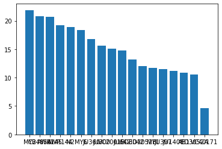

```python
# Build our barplot by giving the index as the x-label, and values as the height
plt.bar(x=wormStrain_mean_embryos.index,
        height=wormStrain_mean_embryos)

# Show our plot
plt.show()
```

### 2.1.1 Use the `figure()` to set your figure size

As we can see from our first attempt, the plot is rather small. We definitely have some problems with the basics of this plot and we'll address the first one that might help. This figure could be a little larger so we can see the x-axis labels better. Use the `figure()` method to set your figure size using the `figsize` parameter.

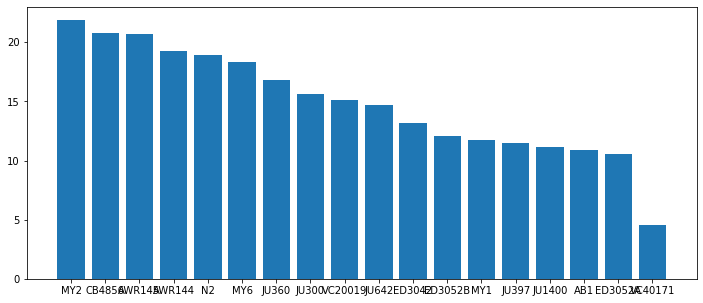

```python
# Fix the size of the plot
plt.figure(figsize = (12,5))

# Build our barplot
plt.bar(x=wormStrain_mean_embryos.index,
        height=wormStrain_mean_embryos)

# Show our plot
plt.show()
```

### 2.1.2 Rotate your x-axis text with the `xticks()` method

Now that our plot is larger, we can still see the x-axis labels are still too large. We can, however, rotate the text and see if that helps. Let's rotate to a 90-degree angle. We'll alter these axis properties through the `xticks()` method.

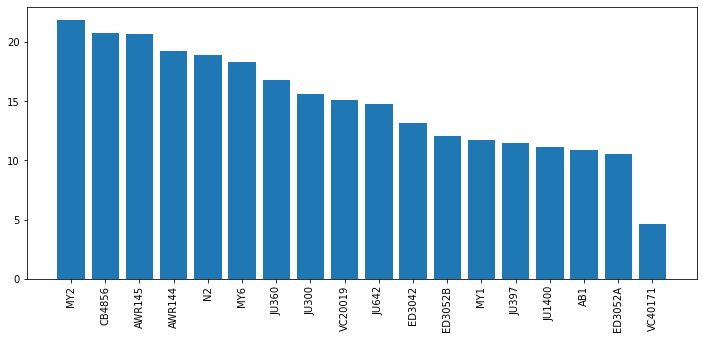

```python
# Fix the size of the plot
plt.figure(figsize = (12, 5))

# Build our barplot
plt.bar(x=wormStrain_mean_embryos.index,
        height=wormStrain_mean_embryos)

# Rotate the x-axis text
plt.xticks(rotation = 90)

# Show our plot
plt.show()
```

### 2.1.3 Add labels to your plot

Okay, the plot is larger and we've fixed our x-axis label issues. No more overcrowding! Let's add a main title and axis titles to our dataset. We can use the `title()`, `xlabel()`, and `ylabel()` methods in this case. While we set the labels, we can also set their properties such as `fontsize`, `fontstyle`, and `color`.

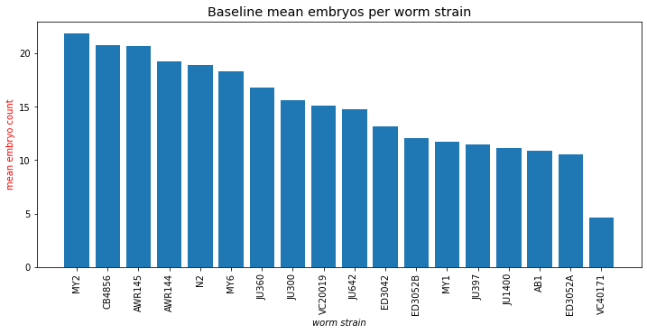

```python
# Fix the size of the plot
plt.figure(figsize = (12, 5))

# Build our barplot
plt.bar(x=wormStrain_mean_embryos.index,
        height=wormStrain_mean_embryos)

# Rotate the x-axis text
plt.xticks(rotation = 90)

# Add titles
plt.title("Baseline mean embryos per worm strain", fontsize = "x-large")
plt.xlabel("worm strain", fontstyle = "italic")
plt.ylabel("mean embryo count", color = "r")

# Show our plot
plt.show()
```

### 2.1.4 Alter properties of your barplot

Similar to altering text properties, most of the plots have the ability to alter various properties like fill and line color or other plot-specific attributes. Let's update the fill and line colours for our barplot using the `color` and `edgecolor` parameters.

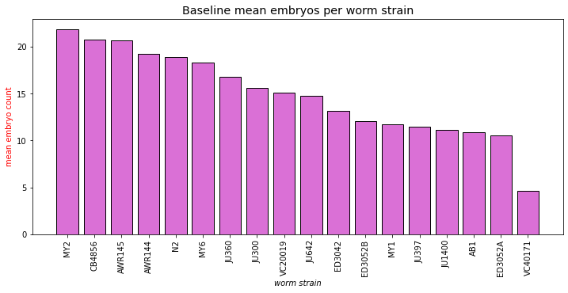

```python
# Fix the size of the plot
plt.figure(figsize = (12, 5))

# Build our barplot
plt.bar(x=wormStrain_mean_embryos.index,
        height=wormStrain_mean_embryos,
        color="orchid",
        edgecolor="black")

# Rotate the x-axis text
plt.xticks(rotation = 90)

# Add titles
plt.title("Baseline mean embryos per worm strain", fontsize = "x-large")
plt.xlabel("worm strain", fontstyle = "italic")
plt.ylabel("mean embryo count", color = "r")

# Show our plot
plt.show()
```

**Section 2.0.0 Comprehension Question** What if we would like to change our x-axis to limit the number of subsites we are displaying? How would you plot just the first 10 values using the **plt.axis()** method? Modify the code below to try and alter the x-axis limits. For more information on how to use this method [check out the documentation](https://matplotlib.org/stable/api/_as_gen/matplotlib.pyplot.axis.html?highlight=pyplot%20axis#matplotlib.pyplot.axis).

```python
?plt.axis
```

```python
# Fix the size of the plot
plt.figure(figsize = (12, 5))

# Build our barplot
plt.bar(x=wormStrain_mean_embryos.index,
        height=wormStrain_mean_embryos,
        color="orchid",
        edgecolor="black")

# Rotate the x-axis text
plt.xticks(rotation = 90)

# Add titles
plt.title("Baseline mean embryos per worm strain", fontsize = "x-large")
plt.xlabel("worm strain", fontstyle = "italic")
plt.ylabel("mean embryo count", color = "r")

# Alter the axis limits
plt.axis(...)

# Show our plot
plt.show()
```

**Learn more about Pyplot:** We've barely scratched the surface of working with the Pyplot module and depending on your needs it may be enough to get along on. You can find more at the [matplotlib tutorial for pyplot](https://matplotlib.org/stable/tutorials/introductory/pyplot.html#sphx-glr-tutorials-introductory-pyplot-py).

# 3.0.0 Basic visualizations with the `seaborn` package

Building upon our visualizations in the last section, there are some common themes you might recognize about them. We have a plot area, x- and y-axis data, axis limits, and plot colors. Using `matplotlib` to help generate your visualizations, you can control many small details but it can also be tedious at times to micromanage so many aspects of your plot.

The `seaborn` package is actually built upon the `pyplot` module and tries to bring a high-level approach to statistical plots. As we'll see later on, this means updating certain details of our plots will require an understanding of the base `matplotlib` and `pyplot` functions.

### 3.0.1 The `seaborn` package subdivides plot types into 3 categories

The `seaborn` package takes a dual-pronged approach to generating plots. There are functions considered to work at the **Figure** level and then there are functions that affect what is known as the **Axes** level. To simplify the concept:

- `Axes`: A single plot defined by an x and y axis grid. This includes all of the basic plots like scatter and box plots.
- `Figure`: A plot space that can range from 1 to multiple `Axes`. The setup of `Axes` can be simple to complex.

At the `Axes` levels, there are 3 categories of plot types based on their similarity: relational, distribution, and categorical. For each of these categories there is a figure-level function that can be used to create multi-panel (faceted) versions of these plots by splitting the data further by categorical variables.

[output not shown]

The above functions are used to initialize figure and axes objects by identifying a number of properties. Within these, some of the options can vary greatly based on plot type. Of the two levels of functions, their influence on figure attributes can vary:

- **Figure-level**: Return a `FacetGrid` object that have some additional methods for altering attributes of the plot in a way that makes sense to the subplot organization.
- **Axes-level**: Add axis labels and legends to the `Axes` they are drawn onto but do not alter the figure in any other way. You can choose to draw onto the current axes in memory OR specify the reference to an axes which may be within a larger figure.

## 3.1.0 Introduction to the Grammar of Graphics

One approach to effective data visualization relies on the Grammar of Graphics framework originally proposed by Leland Wilkinson (2005).The idea of grammar can be summarized as follows:

- Grammar is the foundational set of rules that define the components of a language.
- A language is built on a structure that consists of syntax and semantics.

[figure not shown]

The **grammar of graphics** is a language to communicate about what we are plotting programmatically

- It begins with a **tidy** data frame. It will have a series of **observations** (rows) each of which will be described across multiple **variables** (columns). Variables can actually represent qualitative or quantitative measurements or they could be descriptive data about the experiments or experimental groups.
- The data units may undergo conversion through a process called **scaling** (transformation) before being used for plotting.
- A subset of data columns are then passed on to be presented in various data plots (scatterplots, boxplots, kernel density estimates, etc.) by using the data to describe visual properties of the plot. We call these visual properties, the **aesthetics** of the plot. For example, the data being plotted or represented can be visually altered in shape or colour based on accompanying column data.
- A plot can have multiple layers (for example, a scatter plot with a regression line) and each of these plot types is referred to as a **geom** (short of geometric object).

### 3.1.1 The grammar of graphics with `seaborn`

The grammar of graphics facilitates the concise description of any components of any graphics. Hadly Wickham of R `tidyverse` fame has proposed a variant on this concept - the layered grammar of graphics framework in the `ggplot2` package for R. By following a layered approach of defined components, it can be easy to build a visualization.

In a similar manner, the `seaborn` package has some methods that facilitate a layering approach to building your visualizations. However, many of the details are built upon the foundation of layering `Axes` objects or alterations upon `Figure` objects.

Each Axes-level function usually takes in:

1. `Data`: your visualization always starts here. What are the dimensions you want to visualize. What aspect of your data are you trying to convey?
2. `Aesthetics`: assign your axes based on the data dimensions you have chosen. Where will the majority of the data fall on your plot? Are there other dimensions (such as categorically encoded groupings) that can be conveyed by aspects like size, shape, colour, fill, etc.
3. `Geometric objects`: how will you display your data within your visualization. Which `*plot` will you use?

The figure-level methods can be used to alter or update:

1. `Scale`: do you need alter your x or y-axis limits? What about scaling/transforming any values to fit your data within a range? Sometimes, depending on the Geometric object, you are better off transforming your data ahead of time.
2. `Facets`: will generating subplots of the data add a dimension to your visualization that would otherwise by lost?
3. `Coordinate system`: will your visualization follow a classis cartesian, semi-log, polar, etc. coordinate system?

Let's jump into our first dataset and start building some plots with it shall we?

### 3.1.2 Import `infection_signal.tsv`

Before we dig into the `seaborn` package, we will import a new dataset that has a slightly more diverse array of data that we can use for showcasing the plotting power of `seaborn`.

```python
# We'll reset the code cells to only show FINAL code output.
InteractiveShell.ast_node_interactivity = "last"
```

```python
# Read the pitlatrine data in from file
infectionSig_data = pd.read_csv("data/infection_signal.tsv", sep = "\t")

# Look at the first 5 rows of data
infectionSig_data.head(5)
```

|  | exp.name | strain | spore.strain | spore.species | dose | spores | fixing.date | slide | file | worm.number | area | percent.infected | area.infected | timepoint |
| --- | --- | --- | --- | --- | --- | --- | --- | --- | --- | --- | --- | --- | --- | --- |
| 0 | N2-LUAm1-1.8 | N2 | LUAm1 | N.ferruginous | pulse-72H | 1.8 | rep1 | 1 | N2.LUAm1.rep1 | 1 | 49838.02 | 18.53 | 9234.985106 | 72hpi |
| 1 | N2-LUAm1-1.8 | N2 | LUAm1 | N.ferruginous | pulse-72H | 1.8 | rep1 | 1 | N2.LUAm1.rep1 | 2 | 50425.04 | 0.00 | 0.000000 | 72hpi |
| 2 | N2-LUAm1-1.8 | N2 | LUAm1 | N.ferruginous | pulse-72H | 1.8 | rep1 | 1 | N2.LUAm1.rep1 | 3 | 45532.67 | 31.16 | 14187.979970 | 72hpi |
| 3 | N2-LUAm1-1.8 | N2 | LUAm1 | N.ferruginous | pulse-72H | 1.8 | rep1 | 1 | N2.LUAm1.rep1 | 4 | 46458.55 | 3.88 | 1802.591740 | 72hpi |
| 4 | N2-LUAm1-1.8 | N2 | LUAm1 | N.ferruginous | pulse-72H | 1.8 | rep1 | 1 | N2.LUAm1.rep1 | 5 | 49214.73 | 0.00 | 0.000000 | 72hpi |

```python
# How big is this dataframe?
infectionSig_data.info()
```

```
<class 'pandas.core.frame.DataFrame'>
RangeIndex: 456 entries, 0 to 455
Data columns (total 14 columns):
 #   Column            Non-Null Count  Dtype
---  ------            --------------  -----
 0   exp.name          456 non-null    object
 1   strain            456 non-null    object
 2   spore.strain      456 non-null    object
 3   spore.species     456 non-null    object
 4   dose              456 non-null    object
 5   spores            456 non-null    float64
 6   fixing.date       456 non-null    object
 7   slide             456 non-null    int64
 8   file              456 non-null    object
 9   worm.number       456 non-null    int64
 10  area              456 non-null    float64
 11  percent.infected  456 non-null    float64
 12  area.infected     456 non-null    float64
 13  timepoint         456 non-null    object
dtypes: float64(4), int64(2), object(8)
memory usage: 50.0+ KB
```

```python
# What are the unique values in each column?
infectionSig_data.apply(pd.unique, axis = 0)
```

```
exp.name            [N2-LUAm1-1.8, JU1400-LUAm1-1.8, AWR144-LUAm1-...
strain                                   [N2, JU1400, AWR144, AWR145]
spore.strain                                                  [LUAm1]
spore.species                                         [N.ferruginous]
dose                                                      [pulse-72H]
spores                                                          [1.8]
fixing.date                                        [rep1, rep2, rep3]
slide                                                             [1]
file                [N2.LUAm1.rep1, JU1400.LUAm1.rep1, AWR144.LUAm...
worm.number         [1, 2, 3, 4, 5, 6, 7, 8, 9, 10, 11, 12, 13, 14...
area                [49838.02, 50425.04, 45532.67, 46458.55, 49214...
percent.infected    [18.53, 0.0, 31.16, 3.88, 23.54, 1.65, 8.6, 18...
area.infected       [9234.985106, 0.0, 14187.97997, 1802.59174, 93...
timepoint                                                     [72hpi]
dtype: object
```

Taking a quick look at our data we can summarize it briefly here and see that there are a few categories we can explore across variables like `strain` and `fixing.date` for measured variables like `area` (total area of a worm), `area.infected` (infection signal area) and `percent.infected` (infected area as a % of the total).

## 3.2.0 Build a scatterplot using the `relplot()` method

For the basic plot `relplot()`, we'll start with the following parameters:

- `data`: The tidy (long-form) data set we want to visualize.
- `x`, `y`: The variable names for assigning x- and y-axis values.
- `height`: The total height of our figure.
- `aspect`: A scalar value used to determine the width of your figure (width = height * aspect).
- `kind`: The type of plot we want to produce: scatter (default) vs line
- `kwargs`: This is a catch-all for *any other* keyword arguments that could be passed onto underlying functions like the `Axes`-level methods.

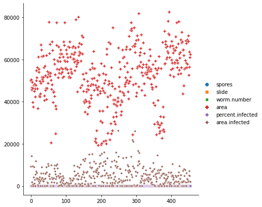

```python
# Import your seaborn package
import seaborn as sns

# We'll build a scatterplot
snsPlot = sns.relplot(data = infectionSig_data,   # Set the data
                      height = 6, aspect = 1,   # Set the size of the figure
                      kind = "scatter"          # Set the figure type
                     )

# Show the plot
plt.show()
```

Looking at the output we can see that without having specified the x and y axis values, it simply plotted all of the variables along a default x-axis of index number (456 rows total). Let's try again by setting our axis variables.

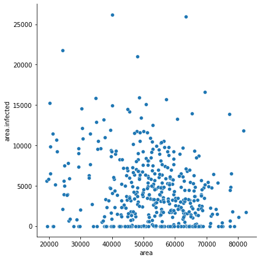

```python
# We'll build a scatterplot
snsPlot = sns.relplot(data = infectionSig_data,
                      x = "area", y = "area.infected",     # Set the axis variables
                      height = 6, aspect = 1,
                      kind = "scatter"
                     )

# Show the plot
plt.show()
```

### 3.2.1 Specify colouring by category with the `hue` parameter

Now we begin to see the power of having a tidy DataFrame. Since each of our observations is in its own row, we can classify each observation by factors like `strain`! Using the `seaborn` package, we can specify the colour of our points using the `hue` parameter. Since we have set the `data = infectionSig_data` parameter, we can tell `seaborn` to look at a specific column when determining the `hue` parameter.

At the same time, we'll set the `alpha` parameter which is essentially the opacity of each datapoint. Setting a lower value increases transparency which allows us to see overlapping datapoints better. This parameter becomes especially helpful when working with extremely dense datapoints.

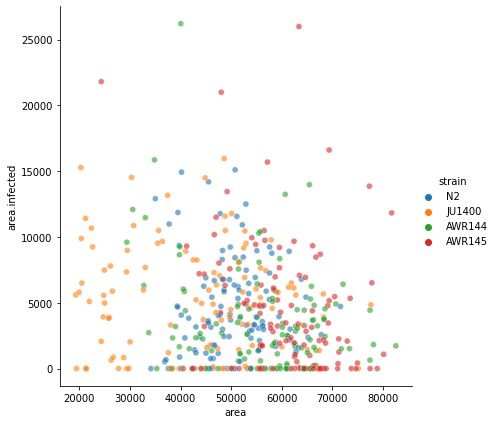

```python
# We'll build a scatterplot
snsPlot = sns.relplot(data = infectionSig_data,
                      x = "area", y = "area.infected",
                      hue = "strain",          # Set the point-colour by strain
                      alpha = 0.6,              # Set the transparency of the points
                      height = 6, aspect = 1,
                      kind = "scatter"
                     )

# Show the plot
plt.show()
```

### 3.2.2 Alter your axis scale with the `set` method

The `set()` method is a gateway to altering a number of aspects of your plot. Once we have our plot saved as an object named `snsplot` we can alter or set some of it's properties this way. In particular we will be using the `yscale` parameter to set adjust the y-axis log scale.

**More on figure attributes:** For a full list of plot attributes you can update through this method you can visit the [Matplotlib help page](https://matplotlib.org/stable/api/_as_gen/matplotlib.axes.Axes.set.html?highlight=set#matplotlib.axes.Axes.set).

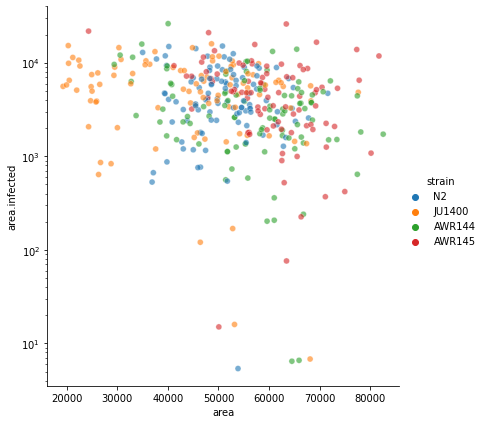

```python
# We'll build a scatterplot
snsPlot = sns.relplot(data = infectionSig_data,
                      x = "area", y = "area.infected",
                      hue = "strain",          # Set the point-colour by strain
                      alpha = 0.6,              # Set the transparency of the points
                      height = 6, aspect = 1,
                      kind = "scatter"
                     )

# Change your y-axis to a log scale
snsPlot.set(yscale="log")

# Show the plot
plt.show()
```

### 3.2.3 Facet your data into different plots with the `relplot()` method

If we want to split our data into multiple new plots based on certain variables, this is known as faceting your data. Usually this results in a grid-like pattern where data is grouped by categories of one variable as columns, and another variable by rows. Although the data could simply be split on a single variable instead. Either way, this generates a figure-level object known as a `FacetGrid()`.

The `relplot()` method already has the capability to handle this splitting of axes within the figure it generates. The `relplot()` method can facet data across two variables using the `row` and `col` parameters. We simply need to name the variable(s) that will be used to categorize the data.

To summarize, the parameters to use for this operation are:

- `col`: The variable name that will be used to group the columns of your grid.
- `row`: The variable name that will be used to group the rows of your grid.

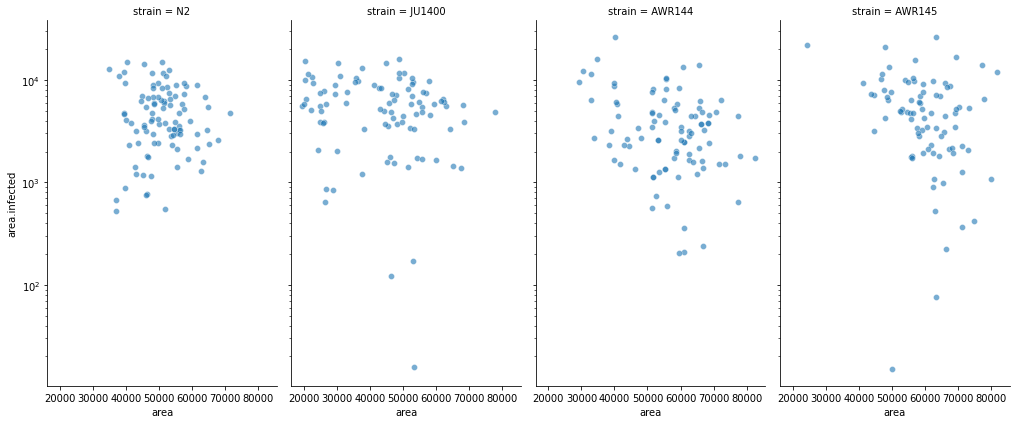

```python
# We'll build a scatterplot
snsPlot = sns.relplot(data = infectionSig_data,
                      x = "area", y = "area.infected",
                      alpha = 0.6,               # Set the transparency of the points
                      height = 6, aspect = 0.6,  # Set the size of the figure
                      kind = "scatter",
                      col = "strain"             # Split the columns of the grid by country
                     )

# Change your y-axis to a log scale
snsPlot.set(yscale="log")

# Show the plot
plt.show()
```

### 3.2.4 Use a continuous variable to colour your data

It is easy enough to set this dimension using the `hue` parameter in our initial `relplot()` call. We'll also set the `palette` parameter to a different colour. We'll also take a second to set the `edgecolor` parameter so that our lower-value/white points can still be seen.

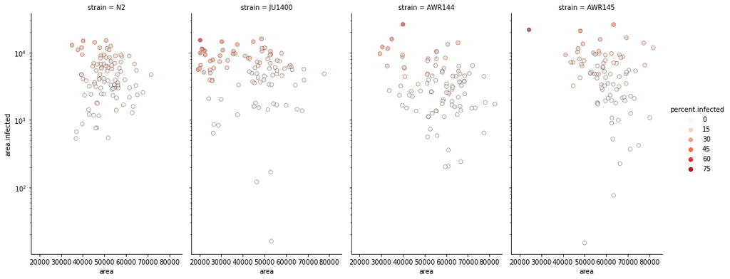

```python
# We'll build a scatterplot
snsPlot = sns.relplot(data = infectionSig_data,
                      x = "area", y = "area.infected",
                      hue = "percent.infected", palette = "Reds",   # Set the point-colour by percent infected
                      edgecolor = "black",       # Set the point border colour so we can see them all
                      alpha = 0.6,
                      height = 6, aspect = 0.6,
                      kind = "scatter",
                      col = "strain"             # Split the columns of the grid by country
                     )

# Change your y-axis to a log scale
snsPlot.set(yscale="log")

# Show the plot
plt.show()
```

### 3.2.5 Update your axis using the `set_axis_labels()` method

The names of our axis titles are drawn from the variable names we used for the original `DataFrame` but we may be limited in how those variables are originally named. In other cases you may wish to add units, or simply make your axis titles more descriptive. To accomplish this we can alter our labels directly using the `set_axis_labels()` method. The parameters to set are `x_var` and `y_var` in that order. Set them directly if you only want to change a single axis title.

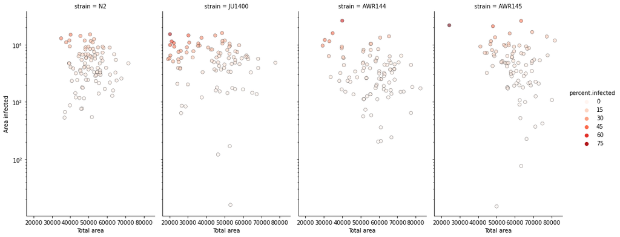

```python
# We'll build a scatterplot
snsPlot = sns.relplot(data = infectionSig_data,
                      x = "area", y = "area.infected",
                      hue = "percent.infected", palette = "Reds",   # Set the point-colour by percent infected
                      edgecolor = "black",       # Set the point border colour so we can see them all
                      alpha = 0.6,
                      height = 6, aspect = 0.6,
                      kind = "scatter",
                      col = "strain"             # Split the columns of the grid by country
                     )

# Set the axis titles (Aesthetics)
snsPlot.set_axis_labels(x_var = "Total area", y_var = "Area infected")

# Change your y-axis to a log scale
snsPlot.set(yscale="log")

# Show the plot
plt.show()
```

### 3.2.6 Set the shape of your points with the `style` parameter

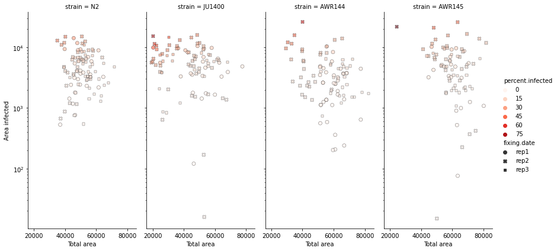

```python
# We'll build a scatterplot
snsPlot = sns.relplot(data = infectionSig_data,
                      x = "area", y = "area.infected",
                      hue = "percent.infected", palette = "Reds",   # Set the point-colour by percent infected
                      edgecolor = "black",       # Set the point border colour so we can see them all
                      style = "fixing.date",
                      alpha = 0.6,
                      height = 6, aspect = 0.5,
                      kind = "scatter",
                      col = "strain"             # Split the columns of the grid by country
                     )

# Set the axis titles (Aesthetics)
snsPlot.set_axis_labels(x_var = "Total area", y_var = "Area infected")

# Change your y-axis to a log scale
snsPlot.set(yscale="log")

# Show the plot
plt.show()
```

## 3.3.0 Plotting theoretical distributions

Now that we have some of the basics, it's time to take a closer look at using other types of plots. Let's return to our embryo data in `embryo_merged_subset`. It has a lot of nice population-based data that we can dissect to look at theoretical distributions.

### 3.3.1 Filter your data with the boolean AND operator: `&`

We'll focus our dataset first by filter for just the `N2` strain in the mock infection condition. To accomplish this we'll use the conditional AND `&` operator which can combine our boolean expressions. To accompany this, you can also use the conditional OR `|` and we've already seen the logical NOT `~` which can convert our boolean to it's opposites.

Along with this, each boolean expression *must be* separately enclosed by the parentheses syntax `( )`. We'll talk more about this next time in **Lecture 05**. For now, we'll save the filtered data into the object `N2_mock_data`.

```python
# Change the value of ast_node_interactivity
# InteractiveShell.ast_node_interactivity = "all"

# Filter the data by N2 animals with a pathogenDose of 0
N2_mock_data = embryo_merged_subset.loc[(embryo_merged_subset['wormStrain'] == "N2") &
                                        (embryo_merged_subset['pathogenDose'] == 0),
                                       :]

# Check on the data created
N2_mock_data.info()
```

```
<class 'pandas.core.frame.DataFrame'>
Int64Index: 720 entries, 503 to 10748
Data columns (total 19 columns):
 #   Column             Non-Null Count  Dtype
---  ------             --------------  -----
 0   worm.number        720 non-null    int64
 1   date               720 non-null    int64
 2   wormStrain         720 non-null    object
 3   pathogenStrain     720 non-null    object
 4   pathogenDose       720 non-null    float64
 5   doseLevel          720 non-null    object
 6   timepoint          720 non-null    object
 7   merontsPresent     720 non-null    bool
 8   sporesPresent      720 non-null    bool
 9   numEmbryos         720 non-null    int64
 10  experiment         720 non-null    object
 11  experimenter       720 non-null    object
 12  description        720 non-null    object
 13  Infection Date     720 non-null    int64
 14  Plate Number       720 non-null    int64
 15  Total Worms        720 non-null    int64
 16  Spore Lot          720 non-null    object
 17  Lot concentration  720 non-null    int64
 18  Total ul spore     720 non-null    float64
dtypes: bool(2), float64(2), int64(7), object(8)
memory usage: 102.7+ KB
```

### 3.3.2 Look at your distribution as a kernel density estimate with `kdeplot()` or `displot()`

There are a lot of datapoints in our new dataset. This time our measurements are based on the `numEmbryos` for specific uninfected worms within different replicate experiments. A quick question we already investigated was to identify the overall distributions of our embryo numbers across different replicates for all of our strains. We can, however, also visualize this data as a distribution.

A quick way to answer this question is by generating a kernel density estimate (KDE) using the `displot()` method from `seaborn`. We'll need to provide an `x` value (`numEmbryos` in this case) and we'll colour our plots based on `date` variable which is coded as a series of integers which should represent our separate experimental replicates.

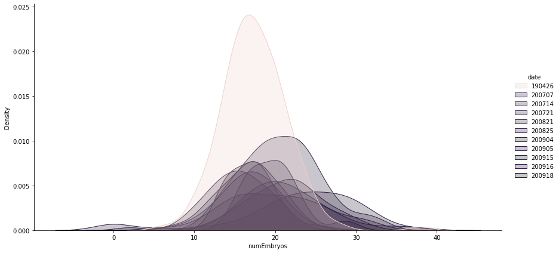

```python
# We'll build a KDE plot
snsPlot = sns.displot(data = N2_mock_data,
                      x = "numEmbryos",
                      hue = "date",
                      height = 6, aspect = 2,
                      kind = "kde",
                      fill = True,             # The fill parameter is passed on to kdeplot()
                     )
# Show the plot
plt.show()
```

Why do we only have 2 colours in our distribution plot? We can see all of the various dates, BUT only the first is really coloured and the others all have a darker hue. It is very reminiscent of when we coloured our scatterplot by the `hue` parameter as well. However, should the values in `date` be considered as numbers or as separate groups?

### 3.3.3 The `category` data type reassigns order or meaning to your values

Sometimes when we work with our data, we may produce what *look* like numerical values for a variable like a replicate number or serial number. However, these values aren't just numbers but really grouping values just like we have in our `wormStrain` variable. Python/pandas doesn't differentiate on this idea inherently when passing data around because it has not insight into our intentions. Moreover when we work with the `seaborn` package - it will also treat integers and floats just like integers and floats.

Recall in **section 3.3.1** we looked at the dtype values in our DataFrame and the `date` variable was an `int64`. What we want is some other way to represent this data. We could convert it to a string `str` BUT we'll introduce a better dtype called the `category`.

Categorical variables are very handy when working with statistical analysis and help to define groups but can also give them an order of importance. This means when analysing or plotting the data, this specific order can be used to determine how that data is used or displayed.

To start off simple, let's convert our `date` variable to a `category` data type and see how that affects out KDE plot.

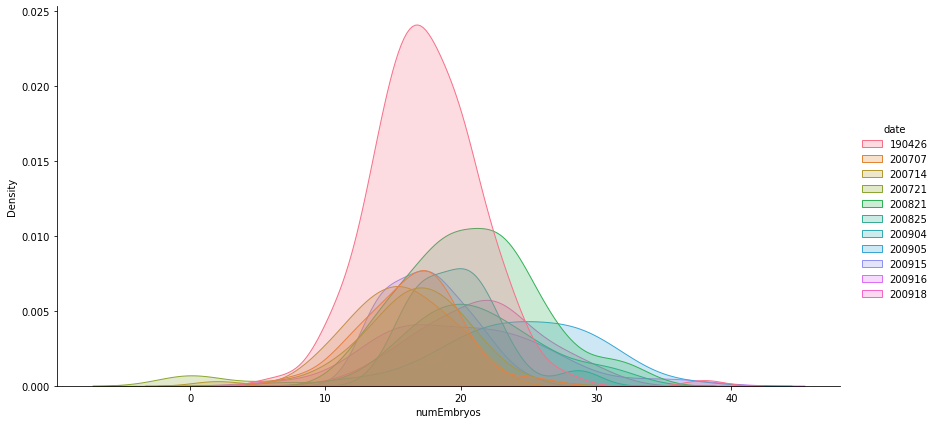

```python
# Convert our date variable with the astype() method
N2_mock_data = N2_mock_data.astype({'date':'category'})

# rebuild a KDE plot
snsPlot = sns.displot(data = N2_mock_data,
                      x = "numEmbryos",
                      hue = "date",
                      height = 6, aspect = 2,
                      kind = "kde",
                      fill = True,             # The fill parameter is passed on to kdeplot()
                     )
# Show the plot
plt.show()
```

It worked! Now we can see that each date has been given a distinct colour!

### 3.3.3.1 Reverse the order of a list using slicing notation

So right now we can see the order of our data has been set by the date values with our earliest date (190426) on top and our latest date (200918) on the bottom. When defining categorical data, you can also define the order of your data. To help us out, we'll grab an array of the unique elements in our `date` variable and then we can use the slicing notation `[::-1]` to reverse our array.

```python
# Convert our date variable back to an int the astype() method
# N2_mock_data = N2_mock_data.astype({'date':'category'})

# Take the unique values and flip the order
date_list = N2_mock_data.date.unique()[::-1].tolist()

# View the reversed date list
date_list
```

```
[200916,
 200905,
 200918,
 200915,
 200904,
 200825,
 200821,
 200721,
 200714,
 200707,
 190426]
```

### 3.3.3.2 Reorder your categories with `reorder_categories()`

Now that we have a reverse list of our categories (or you could make a custom list of course), you can replace the `date` column in our dataset. To alter teh categorical information, you must access the `.cat` property and use the `.reorder_categories()` method on it. This will return a *new* Categorical object which you must use to replace the original `date` data.

We'll take a look at our update KDE plot afterwards and see if it worked!

```python
# We'll need to pull out and replace the date column
N2_mock_data['date'] = (N2_mock_data['date']
                        # access the categorical property
                        .cat
                        # Reorder the categorical data
                        .reorder_categories(new_categories = date_list)
                       )

# Double-check the date column results
N2_mock_data['date']
```

```
503      190426
504      190426
505      190426
506      190426
507      190426
          ...
10744    200916
10745    200916
10746    200916
10747    200916
10748    200916
Name: date, Length: 720, dtype: category
Categories (11, int64): [200916, 200905, 200918, 200915, ..., 200721, 200714, 200707, 190426]
```

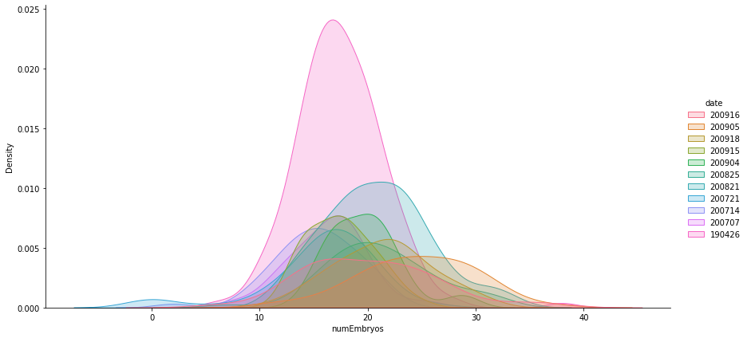

```python
# Rebuild a KDE plot with the new category order
snsPlot = sns.displot(data = N2_mock_data,
                      x = "numEmbryos",
                      hue = "date",            # Now the date variable is a category!
                      height = 6, aspect = 2,
                      kind = "kde",
                      fill = True,             # The fill parameter is passed on to kdeplot()
                     )
# Show the plot
plt.show()
```

### 3.3.4 Add a `rugplot()` to the margin

Within `seaborn` there are a few ways marginal plots that can be added to your visualizations. Marginal plots usually add distribution summaries like a histogram, kde or in our case, a rugplot. More specifically, we'll be using the `rugplot()` method but there is also the ability to create certain plot combinations using the `jointplot()` method.

A rugplot is simply a series of vertical or horizontal tick-marks representing our actual data points along the x- and/or y-axis. For our rugplot, we'll be add it outside of our plot area by manipulating the `height` and `clip_on` parameters to help us out. We'll also set the `alpha` parameter to help us see the density of our tick marks a little better. Despite where it is plotted, we are adding this plot on the underlying `Axes` object of the current `snsPlot` figure.

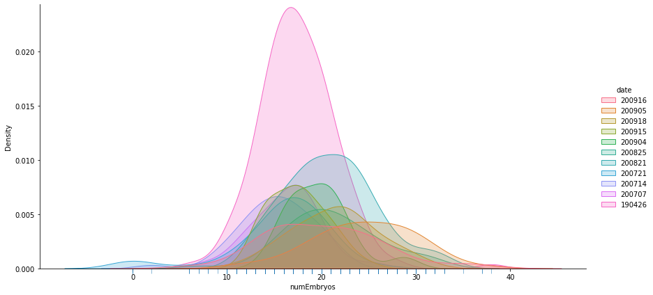

```python
# We'll build a KDE plot
snsPlot = sns.displot(data = N2_mock_data,
                      x = "numEmbryos",
                      hue = "date",            # Now the date variable is a category!
                      height = 6, aspect = 2,
                      kind = "kde",
                      fill = True,             # The fill parameter is passed on to kdeplot()
                     )

# Add a rugplot - this is plotted on top of the current axes object
sns.rugplot(data = N2_mock_data,
            x = "numEmbryos",
            height = -0.02, clip_on = False,
            alpha = 0.5
           )

# Show the plot
plt.show()
```

## 3.4.0 Boxplots provide visual summary statistics of your data

Boxplots are a great way to visualize summary statistics for your data. As a reminder, the thick line in the center of the box is the **median**. The upper and lower ends of the box are the first and third **quartiles** (or 25th and 75th percentiles) of your data. The whiskers extend to the largest value no further than 1.5*IQR (inter-quartile range - the distance between the first and third quartiles).

Data beyond these whiskers are considered outliers and plotted as individual points. This is a quick way to see how comparable your samples or variables are.

### 3.4.1 Generate a basic boxplot with the `catplot()` method

The `catplot()` method is the gateway to more categorical plots and behaves similarly to the other two figure-level plots we've encountered.

Before we begin, we'll summarize the data again as we did earlier in **section 1.3.0** but this time we'll also include an extra level to group by in `doseLevel`.

As well, we'll use the `.isin()` method to help us filter. This method will apply an element-wise determination if the element is within a supplied list of values

```python
# Filter for only uninfected data
mean_Embryo_data = (embryo_merged_subset.loc[embryo_merged_subset['doseLevel']
                                             .isin(values = ["Mock", "Medium"])] # filter by doseLevel

                    # Group by infection experiment
                    .groupby(by = ['date', 'wormStrain', 'pathogenStrain', 'doseLevel'])

                    # Create the frequency table on numEmbryos
                    ['numEmbryos']
                    .agg('mean')

                    # Recall, when we reset the index, it converts the indices back into columns
                    .reset_index()

                    .astype({'doseLevel':'category'})
)

# Check out our summarized data
mean_Embryo_data
```

|  | date | wormStrain | pathogenStrain | doseLevel | numEmbryos |
| --- | --- | --- | --- | --- | --- |
| 0 | 190426 | AB1 | LUAm1 | Medium | 8.583333 |
| 1 | 190426 | AB1 | LUAm1 | Mock | 10.903226 |
| 2 | 190426 | CB4856 | ERTm5 | Medium | 17.484375 |
| 3 | 190426 | CB4856 | ERTm5 | Mock | 20.750000 |
| 4 | 190426 | ED3042 | LUAm1 | Medium | 2.352941 |
| ... | ... | ... | ... | ... | ... |
| 138 | 200916 | N2 | ERTm5-96H | Mock | 20.140000 |
| 139 | 200918 | AWR144 | ERTm5 | Mock | 20.060000 |
| 140 | 200918 | AWR145 | ERTm5 | Mock | 21.760000 |
| 141 | 200918 | JU1400 | ERTm5 | Mock | 14.140000 |
| 142 | 200918 | N2 | ERTm5 | Mock | 21.360000 |

143 rows × 5 columns

Now we can build our boxplot using the summarized data!

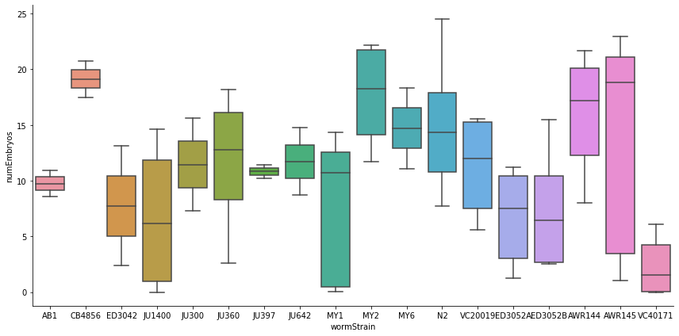

```python
# Use catplot to make our boxplot
snsPlot = sns.catplot(data = mean_Embryo_data,
                      x = "wormStrain", y = "numEmbryos",
                      kind = "box", # Make a boxplot
                      height = 6, aspect = 2 # Set the width of our plot to 4 and width at 12
                     )

# Show the plot
plt.show()
```

### 3.4.2 Rotate your x-axis through the `set_xticklabels()` method

We've encountered this problem before the the solution is actually the same. Recall that `seaborn` is built upon the back of the `pyplot` module so we can actually modify the plot directly through pyplot!

We'll rotate the x-axis text with the `set_xticklabels()` method on our plot object to 90 degrees.

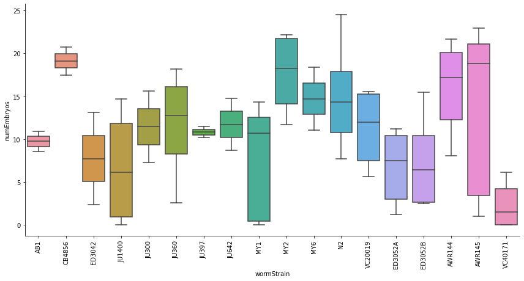

```python
# Use catplot to make our boxplot
snsPlot = sns.catplot(data = mean_Embryo_data,
                      x = "wormStrain", y = "numEmbryos",
                      kind = "box",                        # Make a boxplot
                      height = 6, aspect = 2
                     )

# Alter the xtick attributes
snsPlot.set_xticklabels(rotation = 90)

# Show the plot
plt.show()
```

### 3.4.4 Generate nested boxplots using the `hue` parameter

We'll also set the `boxplot()` parameter `width` to put a little more distance between each category along the x-axis. This value usually ranges between 0 and 1.

To save on some space we'll additionally move the legend into the plot using the `legend_out` boolean parameter.

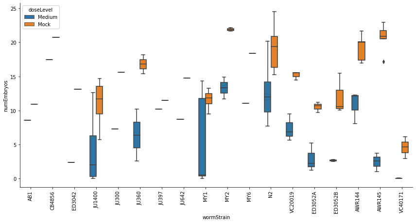

```python
# Use catplot to make our boxplot
snsPlot = sns.catplot(data = mean_Embryo_data,
                      x = "wormStrain", y = "numEmbryos",
                      kind = "box",                        # Make a boxplot
                      height = 6, aspect = 2,
                      hue = "doseLevel",
                      legend_out = False,        # Move the legend inside the plot
                      width = 0.6                # Put some more distance between categories by decreasing width
                     )

# Alter the xtick attributes
snsPlot.set_xticklabels(rotation = 90)

# Show the plot
plt.show()
```

Let's take a moment to fix our `doseLevel` category so that we plot the "Mock" data before the infected data for our boxplot. Remember,w e can use the `.reorder_categories()` to accomplish this

```python
# Pull out our doseLevel data and replace it with a newly categorized version
mean_Embryo_data['doseLevel'] = (mean_Embryo_data['doseLevel']
                                 .cat
                                 .reorder_categories(new_categories = ["Mock", "Medium"])
                                )

# Double check it worked
mean_Embryo_data['doseLevel'].cat.categories
```

```
Index(['Mock', 'Medium'], dtype='object')
```

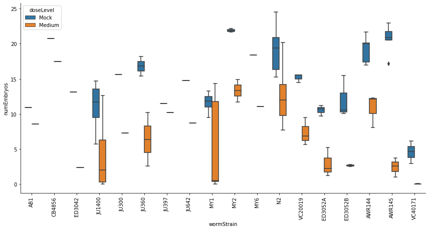

```python
# Use catplot to make our boxplot
snsPlot = sns.catplot(data = mean_Embryo_data,
                      x = "wormStrain", y = "numEmbryos",
                      kind = "box",                        # Make a boxplot
                      height = 6, aspect = 2,
                      hue = "doseLevel",
                      legend_out = False,        # Move the legend inside the plot
                      width = 0.6                # Put some more distance between categories by decreasing width
                     )

# Alter the xtick attributes
snsPlot.set_xticklabels(rotation = 90)

# Show the plot
plt.show()
```

### 3.4.5 Facet your crowded data with the `row` and `col` parameters

So our plot above is quite busy. Whereas previously, we used the `relplot()` method to generate a faceted scatterplot (or relational plot), here we'll use the `catplot()` method to accomplish something similar. The `catplot()` method handles the distribution or faceting of *categorical* plots using similar parameters:

- `col`: The variable name that will be used to group the columns of your grid.
- `row`: The variable name that will be used to group the rows of your grid.

At the same time, we'll play with a few additional methods:

- `set_axis_labels()`: can accept an x and y-axis label in the form of a string. You can also set separate labels with the `set_xlabels` and `set_ylabels` methods.
- `set_xticklabels()`: we already used this to rotate our x-axis text but we also can set the `labels` parameter.
- `set_titles()`: we'll use this to simplify the name of each panel to use just the value from our variable. This is found in string `"{col_name}"`. `"{col_var}"` would use the variable name we're setting our facet by, ie. "wormStrain".

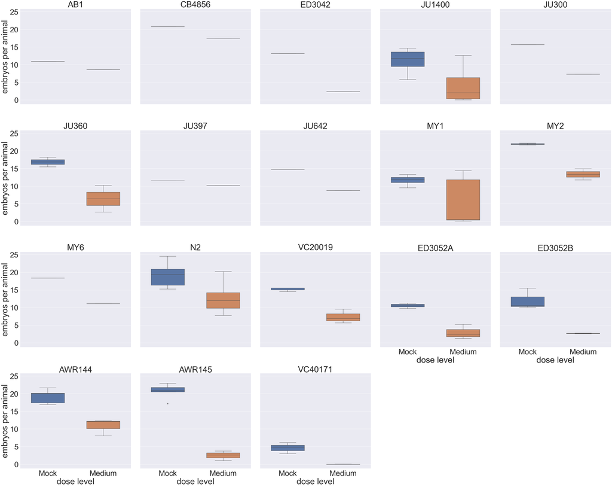

```python
sns.set(font_scale = 4)

# Use catplot to make our boxplot
snsPlot = sns.catplot(data = mean_Embryo_data,
                      x = "doseLevel", y = "numEmbryos",
                      kind = "box",                        # Make a boxplot
                      height = 10, aspect = 1,
                      width = 0.6,                # Put some more distance between categories by decreasing width
                      col = "wormStrain",
                      col_wrap = 5
                     )

# Alter the xtick attributes
snsPlot.set_xticklabels(labels = ["Mock", "Medium"])

# Change our y-axis label
snsPlot.set_axis_labels("dose level", "embryos per animal")

# set the title
snsPlot.set_titles("{col_name}")

# Show the plot
plt.show()
```

### 3.4.6 Overlay on a faceted plot using `map_dataframe()`

Even though boxplots give us summary statistics on our data, it is useful to readers (and reviewers) to be able to see where our individual data points are. We've already used `rugplot()` to help visualize our data distribution in density plots. In that case, we simply plotted on top of the already present *simple* plot.

Similarly, for a boxplot we can add the data as another layer using using an `sns.swarmplot()` to place dots on top of our boxplot. A swarmplot places data points that are overlapping next to each other, so we can get a better picture of the distribution of our data.

In the case of our _facted*boxplot* however, we cannot simply overlay with `sns.swarmplot()`. Instead, we need to map our data using the `.map_dataframe()` method. It will preserve the underlying panel/graph and use it's characteristics to overlay a new plot, potentially with new data. It uses the following parameters:

- `func`: the function we want to overlay. This would be the `sns.swarmplot` in our case. Note the lack of parentheses!
- `args` and `kwargs`: we'll talk more about this next week, but essentially any additional arguments you would normally use for your plotting function, are simply supplied here as named parameters.

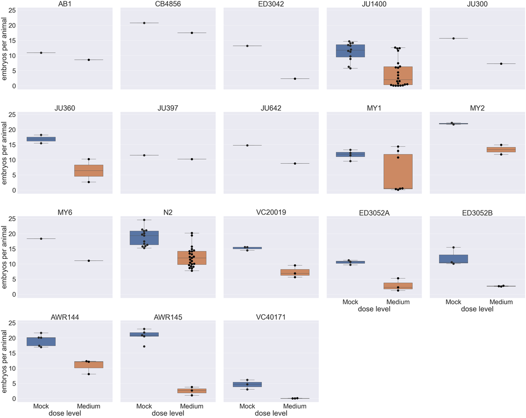

```python
# Use catplot to make our boxplot
snsPlot = sns.catplot(data = mean_Embryo_data,
                      x = "doseLevel", y = "numEmbryos",
                      kind = "box",                        # Make a boxplot
                      height = 10, aspect = 1,
                      width = 0.6,                # Put some more distance between categories by decreasing width
                      col = "wormStrain",
                      col_wrap = 5,
                      fliersize = 0               # Hide our outliers by making them size 0
                     )

# Alter the xtick attributes
snsPlot.set_xticklabels(labels = ["Mock", "Medium"])

# set the title
snsPlot.set_titles("{col_name}")

# Overlay a swarmplot on our catplot
snsPlot.map_dataframe(sns.swarmplot, data = mean_Embryo_data,
                      x = "doseLevel",
                      y = "numEmbryos",
                      hue = "doseLevel",        # split the points by dose level just like nested boxplots
                      palette="dark:black",     # Recolour all of the points to black
                      size=15                   # Set the size of our points so they can be seen
)

# Change our y-axis label. It appears to work best AFTER the map_dataframe() call
snsPlot.set_axis_labels("dose level", "embryos per animal")

# Show the plot
plt.show()
```

## 3.5.0 Use the violin plot to visualize distributions

If you could combine aspects of the boxplot and the KDE into a single visualization, you would think it was the violin plot. Another way to think of the violin plot is as the KDE plot that's been shrunk down and placed categorically.

It's actually quite easy to switch over since many of the aspects are similar to the boxplot. We need only change the `kind` parameter in our `catplot()` code.

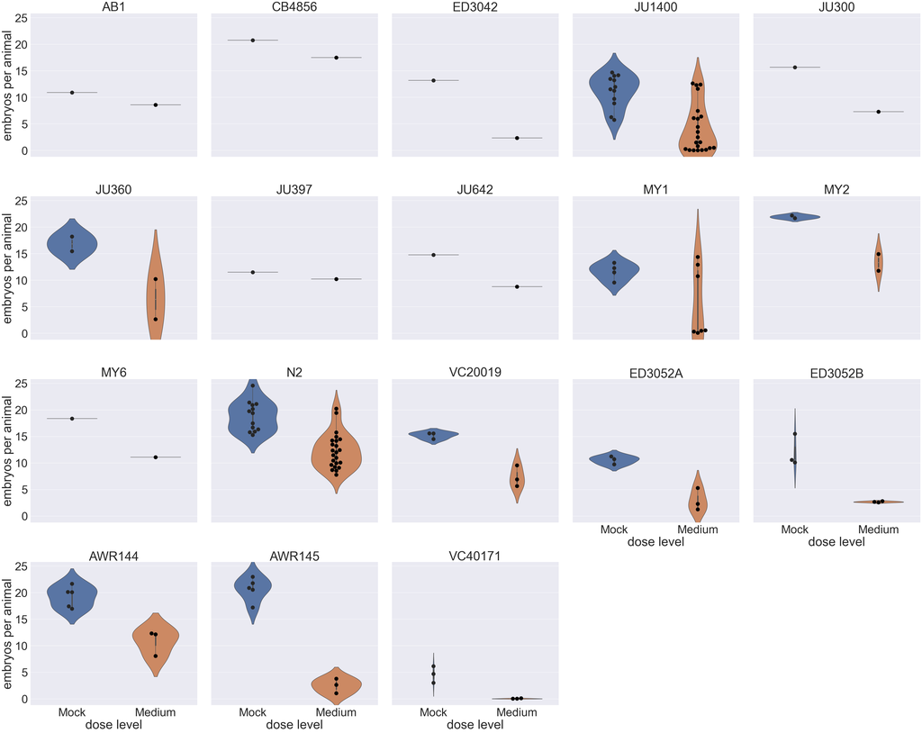

```python
# Use catplot to make our boxplot
snsPlot = sns.catplot(data = mean_Embryo_data,
                      x = "doseLevel", y = "numEmbryos",
                      kind = "violin",                        # Make a violin plot
                      height = 10, aspect = 1,
                      width = 0.6,                # Put some more distance between categories by decreasing width
                      col = "wormStrain",
                      col_wrap = 5,
                      fliersize = 0               # Hide our outliers by making them size 0
                     )

# Alter the xtick attributes
snsPlot.set_xticklabels(labels = ["Mock", "Medium"])

# set the title
snsPlot.set_titles("{col_name}")

# Overlay a swarmplot on our catplot
snsPlot.map_dataframe(sns.swarmplot, data = mean_Embryo_data,
                      x = "doseLevel",
                      y = "numEmbryos",
                      hue = "doseLevel",        # split the points by dose level just like nested boxplots
                      palette="dark:black",     # Recolour all of the points to black
                      size=15                   # Set the size of our points so they can be seen
)

# Change our y-axis label. It appears to work best AFTER the map_dataframe() call
snsPlot.set_axis_labels("dose level", "embryos per animal")

# Show the plot
plt.show()
```

### 3.5.1 Combine a binary grouping with the `split` parameter

Sometimes a more direct comparison of your data can be applied through the violin plot by generating a split version of it. This is especially helpful when you are working with nested data that is binary and you would like to compare it visually.

We'll initialize this visualization with the `split` boolean parameter. To help with this visualization we'll also:

- change the overlay from a `swarmplot` to a `stripplot` to accomodate a more narrow width of the half-violins
- include some `inner` markers of the quartile information in each violin
- switch up the colours here with the `palette` parameter which accepts a dictionary-like object too!

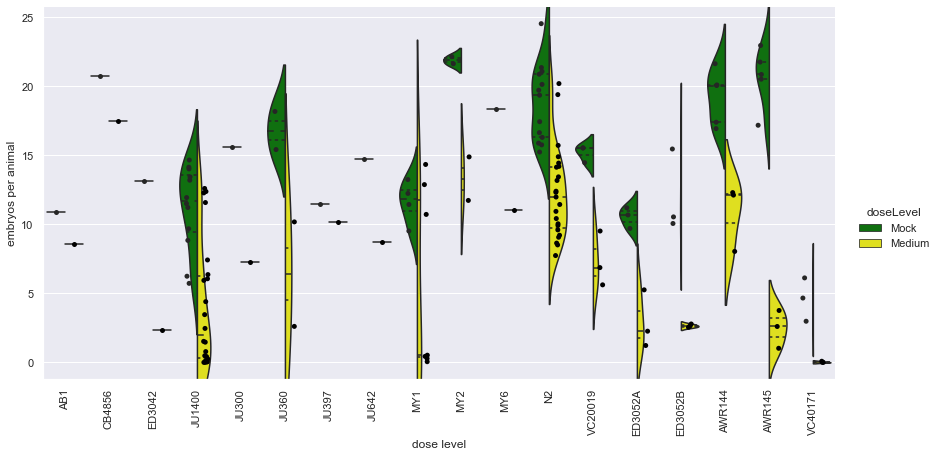

```python
sns.set(font_scale = 1)

# Use catplot to make our boxplot
snsPlot = sns.catplot(data = mean_Embryo_data,
                      x = "wormStrain", y = "numEmbryos",
                      kind = "violin",                        # Make a boxplot
                      height = 6, aspect = 2,
                      hue = "doseLevel",
                      split = True,              # This will create hybrid violin plots
                      inner = "quartile",         # Add quartile markers to each half of the violin
                      palette = {"Mock":"green", "Medium": "yellow"}
                     )

# Overlay a swarmplot on our catplot
snsPlot.map_dataframe(sns.stripplot, data = mean_Embryo_data,
                      x = "wormStrain",
                      y = "numEmbryos",
                      hue = "doseLevel",        # split the points by dose level just like nested boxplots
                      palette="dark:black",     # Recolour all of the points to black
                      size=5,                   # Set the size of our points so they can be seen
                      dodge = True
)

# Change our y-axis label. It appears to work best AFTER the map_dataframe() call
snsPlot.set_axis_labels("dose level", "embryos per animal")

# Alter the xtick attributes
snsPlot.set_xticklabels(rotation = 90)

# Show the plot
plt.show()
```

# 4.0.0 Saving your plots to file

Up until now, we have taken for granted that our plots have been displayed using a *Graphic Device*. For our Jupyter Notebooks we can see the graphs right away and update our code. You can even save them manually from the output display but sometimes you may be producing multiple visualizations based on large data sets. In this case it is preferable to save them directly to file.

## 4.1.0 Save your figures with `plt.savefig()` method

Once you have a figure the way you want it, you can save in any number of graphical and non-graphical formats. The `savefig()` method from the `pyplot` package is here to save the day. Saving the current figure, you can use some of the following parameters:

- `fname`: The path to your file you want to save, including the extension. If `format` is not set, then the file extension will be used to *infer* the format instead.
- `dpi`: The resolution in dots per inch for your figure.
- `format`: The file format you'd like to use. Supported filetypes include svg, jpg, eps, and pdf.

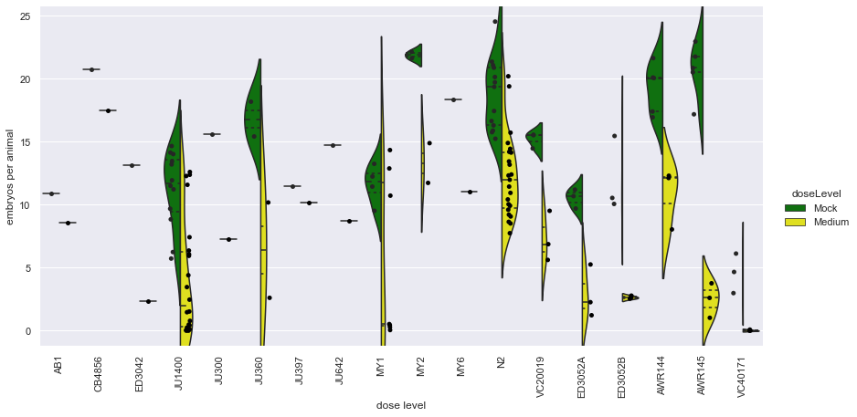

```python
# Use catplot to make our boxplot
snsPlot = sns.catplot(data = mean_Embryo_data,
                      x = "wormStrain", y = "numEmbryos",
                      kind = "violin",                        # Make a boxplot
                      height = 6, aspect = 2,
                      hue = "doseLevel",
                      split = True,              # This will create hybrid violin plots
                      inner = "quartile",         # Add quartile markers to each half of the violin
                      palette = {"Mock":"green", "Medium": "yellow"}
                     )

# Overlay a swarmplot on our catplot
snsPlot.map_dataframe(sns.stripplot, data = mean_Embryo_data,
                      x = "wormStrain",
                      y = "numEmbryos",
                      hue = "doseLevel",        # split the points by dose level just like nested boxplots
                      palette="dark:black",     # Recolour all of the points to black
                      size=5,                   # Set the size of our points so they can be seen
                      dodge = True
)

# Change our y-axis label. It appears to work best AFTER the map_dataframe() call
snsPlot.set_axis_labels("dose level", "embryos per animal")

# Alter the xtick attributes
snsPlot.set_xticklabels(rotation = 90)

# Save the plot
plt.savefig("data/mean_embryos_byStrain.png",
            format = "png",
            dpi = 300
           )
```

# 5.0.0 Plotting multi-panel figures

Up until now we've been generating a combination of either faceted plots or simply layering elements upon single plots. Throughout all of these we have not really been mixing the *types* of plots we've generated. Luckily for us, the `matplotlib.pyplot` module provides a means for us to put together multiple plot axes in a single figure.

We have already seen some of these **figure-level** functions in action with `relplot()` and `catplot()` which provided an interface to **axes-level** methods like `scatterplot()` or `boxplot` when created faceted plots.

[output not shown]

What if, however, we would like to create a figure with multiple axes of different types?

## 5.1.0 Use `subplot2grid()` to generate a multi-grid plot

When generally considering the layout of our data, we want to think of breaking up the figure into a grid. This can start off simply as a 1x1 panel and expand outwards with nested panels within a 2x2 or 3x3 or larger figure. The dimensions also are not limited to square shapes but can be rectangular as well.

The subplot2grid takes the following parameters:

- `shape`: The dimensions of the **figure** given in a (numRow, numCol) tuple. This is essentially the backdrop of all the panels.
- `loc`: The location of the subplot (Axes object) you are creating in relation to the base **figure**. Position (0,0) is the top left corner.
- `rowspan`: The dimensions of the subplot in number of rows.
- `colspan`: The dimensions of the subplot in number of columns.
- `fig`: A figure object to place the Axes object in. Otherwise the current figure is used.

[output not shown]

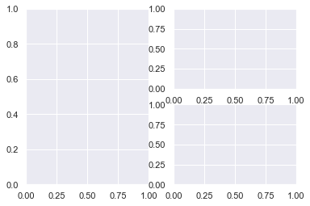

```python
# Initialize a figure
fig = plt.figure()

# Generate 3 subplots onto our current figure
ax1 = plt.subplot2grid(shape = (2, 2), loc = (0,0), colspan = 1, rowspan = 2)
ax2 = plt.subplot2grid(shape = (2, 2), loc = (0,1), colspan=1)
ax3 = plt.subplot2grid(shape = (2, 2), loc = (1,1), colspan=1)

plt.show()
```

### 5.1.1 Use the `Axes` objects as a canvas to plot onto `fig`

Now you can see that our figure encompasses the 3 panels that we envisioned. You'll notice that we named each panel with a reference/variable. We could have also added them to a single list object to save on variable names but to simplify our understanding they've been named separately.

Each of these is a matplotlib.axes.Axes object

There is, however, a quick hitch. We can no longer rely directly on the figure-level functions of `relplot`, `catplot` and `displot`. In order to plot correctly on these subpanels, we'll need to use the axes-level function calls instead. We'll add our plots one at a time so you can see the effect of each.

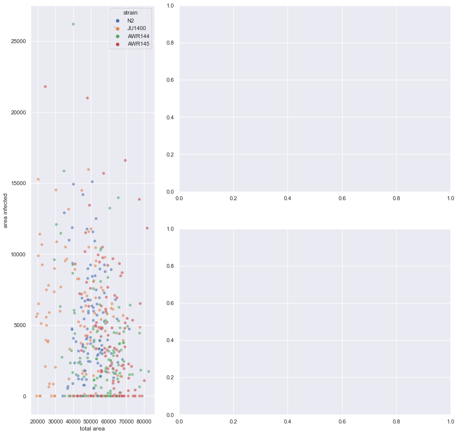

```python
# Initialize a figure
fig = plt.figure(figsize=(15, 15))
# Generate 3 subplots onto our current figure
ax1 = plt.subplot2grid((2, 3), (0, 0), colspan=1, rowspan=2)
ax2 = plt.subplot2grid((2, 3), (0, 1), colspan=2)
ax3 = plt.subplot2grid((2, 3), (1, 1), colspan=2)

# ---------- Plot 1 ----------#
# Add the first plot - scatterplot
# We'll build a scatterplot
sns.scatterplot(data = infectionSig_data,
                x = "area",
                y = "area.infected",
                hue = "strain",          # Set the point-colour by strain
                alpha = 0.6,              # Set the transparency of the points
                ax = ax1
               )

# Directly set the labels on the x-axis and y-axis
ax1.set_xlabel("total area")
ax1.set_ylabel("area infected")

# Show the plot
plt.show()
```

### 5.1.2 Add multiple layers to the second `Axes`

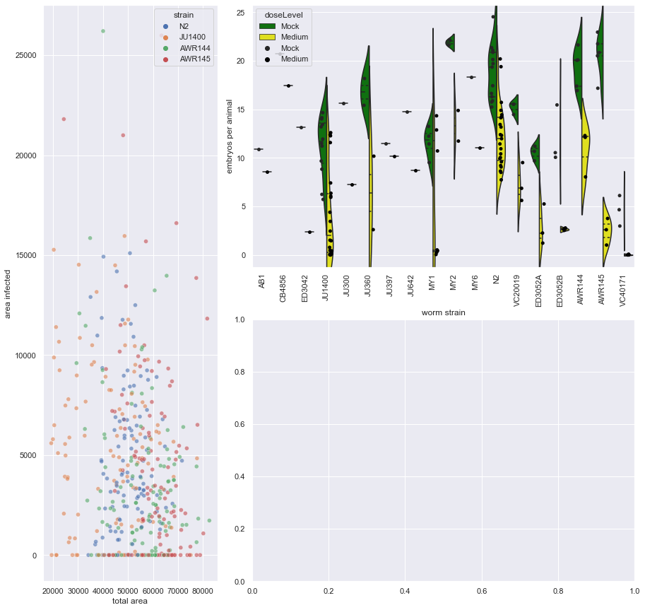

```python
# Initialize a figure
fig = plt.figure(figsize=(15, 15))
# Generate 3 subplots onto our current figure
ax1 = plt.subplot2grid((2, 3), (0, 0), colspan=1, rowspan=2)
ax2 = plt.subplot2grid((2, 3), (0, 1), colspan=2)
ax3 = plt.subplot2grid((2, 3), (1, 1), colspan=2)

# ---------- Plot 1 ----------#
# Add the first plot - scatterplot
# We'll build a scatterplot
sns.scatterplot(data = infectionSig_data,
                x = "area",
                y = "area.infected",
                hue = "strain",          # Set the point-colour by strain
                alpha = 0.6,              # Set the transparency of the points
                ax = ax1
               )

# Directly set the labels on the x-axis and y-axis of ax1
ax1.set_xlabel("total area")
ax1.set_ylabel("area infected")

# ---------- Plot 2 ----------#
# Add the second plot - violin plot
# Use catplot to make our boxplot
sns.violinplot(data = mean_Embryo_data,
               x = "wormStrain", y = "numEmbryos",
               hue = "doseLevel",
               split = True,              # This will create hybrid violin plots
               inner = "quartile",         # Add quartile markers to each half of the violin
               palette = {"Mock":"green", "Medium": "yellow"},
               alpha = 0.6,
               ax = ax2
              )

# Overlay a swarmplot on our catplot
sns.stripplot(data = mean_Embryo_data,
              x = "wormStrain",
              y = "numEmbryos",
              hue = "doseLevel",        # split the points by dose level just like nested boxplots
              palette="dark:black",     # Recolour all of the points to black
              size=5,                   # Set the size of our points so they can be seen
              dodge = True,
              ax = ax2
             )

# Directly set the labels on the x-axis and y-axis of ax2
ax2.set_xlabel("worm strain")
ax2.set_ylabel("embryos per animal")

# Alter the xtick attributes
ax2.tick_params(axis = 'x', rotation = 90)

# Show the plot
plt.show()
```

### 5.1.3 Remove the legend from your plot with `Axes` methods

So you can see there's a slight issue above with our legend in the violin plot. Due to plotting both a violin and strip plot together, we get a legend with both the colouring and the points. The points from the strip plot don't have much meaning so we can remove those easily in the call to `sns.stripplot()` by using the `legend = False` parameter.

If you wanted to remove the legend altogether, you could use the `.get_legend().remove()` command. This would access the `Axes` object legend and remove it.

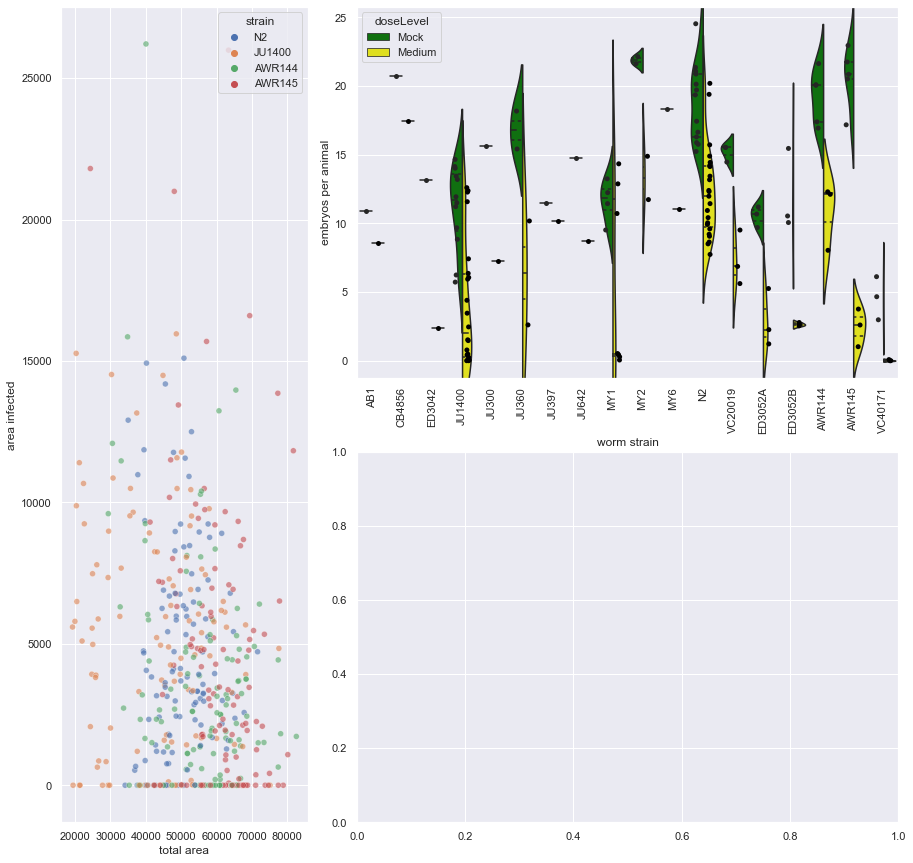

```python
# Initialize a figure
fig = plt.figure(figsize=(15, 15))
# Generate 3 subplots onto our current figure
ax1 = plt.subplot2grid((2, 3), (0, 0), colspan=1, rowspan=2)
ax2 = plt.subplot2grid((2, 3), (0, 1), colspan=2)
ax3 = plt.subplot2grid((2, 3), (1, 1), colspan=2)

# ---------- Plot 1 ----------#
# Add the first plot - scatterplot
# We'll build a scatterplot
sns.scatterplot(data = infectionSig_data,
                x = "area",
                y = "area.infected",
                hue = "strain",          # Set the point-colour by strain
                alpha = 0.6,              # Set the transparency of the points
                ax = ax1
               )

# Directly set the labels on the x-axis and y-axis of ax1
ax1.set_xlabel("total area")
ax1.set_ylabel("area infected")

# ---------- Plot 2 ----------#
# Add the second plot - violin plot
# Use catplot to make our boxplot
sns.violinplot(data = mean_Embryo_data,
               x = "wormStrain", y = "numEmbryos",
               hue = "doseLevel",
               split = True,              # This will create hybrid violin plots
               inner = "quartile",         # Add quartile markers to each half of the violin
               palette = {"Mock":"green", "Medium": "yellow"},
               alpha = 0.6,
               ax = ax2
              )

# Overlay a swarmplot on our catplot
sns.stripplot(data = mean_Embryo_data,
              x = "wormStrain",
              y = "numEmbryos",
              hue = "doseLevel",        # split the points by dose level just like nested boxplots
              palette="dark:black",     # Recolour all of the points to black
              size=5,                   # Set the size of our points so they can be seen
              dodge = True,
              legend = False,           ## Set the legend to false to remove it from the plot
              ax = ax2
             )

# Directly set the labels on the x-axis and y-axis of ax2
ax2.set_xlabel("worm strain")
ax2.set_ylabel("embryos per animal")

# Alter the xtick attributes
ax2.tick_params(axis = 'x', rotation = 90)

# Show the plot
plt.show()
```

### 5.1.4 Add a KDE plot to our final panel

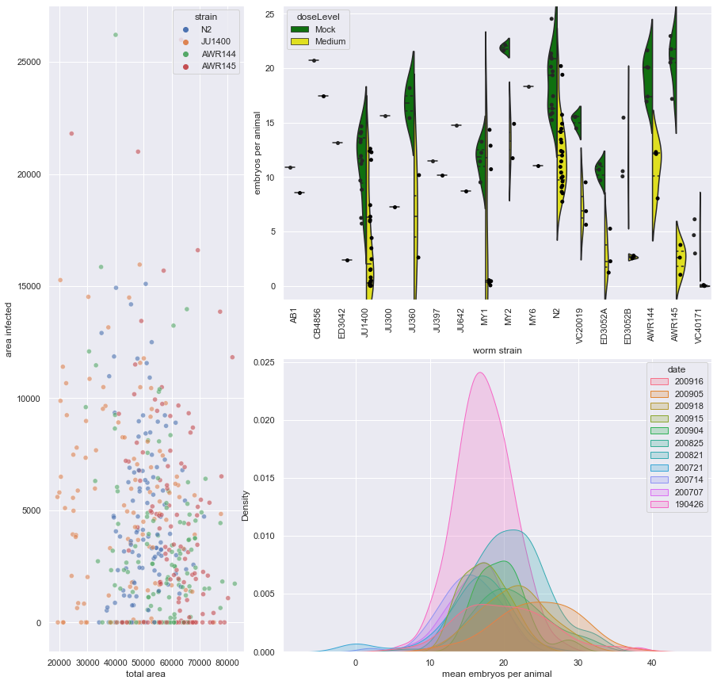

```python
# Initialize a figure
fig = plt.figure(figsize=(15, 15))
# Generate 3 subplots onto our current figure
ax1 = plt.subplot2grid((2, 3), (0, 0), colspan=1, rowspan=2)
ax2 = plt.subplot2grid((2, 3), (0, 1), colspan=2)
ax3 = plt.subplot2grid((2, 3), (1, 1), colspan=2)

# ---------- Plot 1 ----------#
# Add the first plot - scatterplot
# We'll build a scatterplot
sns.scatterplot(data = infectionSig_data,
                x = "area",
                y = "area.infected",
                hue = "strain",          # Set the point-colour by strain
                alpha = 0.6,              # Set the transparency of the points
                ax = ax1
               )

# Directly set the labels on the x-axis and y-axis of ax1
ax1.set_xlabel("total area")
ax1.set_ylabel("area infected")

# ---------- Plot 2 ----------#
# Add the second plot - violin plot
# Use catplot to make our boxplot
sns.violinplot(data = mean_Embryo_data,
               x = "wormStrain", y = "numEmbryos",
               hue = "doseLevel",
               split = True,              # This will create hybrid violin plots
               inner = "quartile",         # Add quartile markers to each half of the violin
               palette = {"Mock":"green", "Medium": "yellow"},
               alpha = 0.6,
               ax = ax2
              )

# Overlay a swarmplot on our catplot
sns.stripplot(data = mean_Embryo_data,
              x = "wormStrain",
              y = "numEmbryos",
              hue = "doseLevel",        # split the points by dose level just like nested boxplots
              palette="dark:black",     # Recolour all of the points to black
              size=5,                   # Set the size of our points so they can be seen
              dodge = True,
              legend = False,           ## Set the legend to false to remove it from the plot
              ax = ax2
             )

# Directly set the labels on the x-axis and y-axis of ax2
ax2.set_xlabel("worm strain")
ax2.set_ylabel("embryos per animal")

# Alter the xtick attributes
ax2.tick_params(axis = 'x', rotation = 90)

# ---------- Plot 3 ----------#
# rebuild a KDE plot
sns.kdeplot(data = N2_mock_data,
            x = "numEmbryos",
            hue = "date",
            fill = True,             # The fill parameter is passed on to kdeplot()
           )

# Directly set the x-axis label
ax3.set_xlabel("mean embryos per animal")

# Show the plot
plt.show()
```